# Racket：一门用于编写编程语言的编程语言 • Robby Findler • YOW! 2015Racket: A Programming-Language Programming Language • Robby Findler • YOW! 2015

## 修改代码以避免重复Changing code to avoid duplicating it

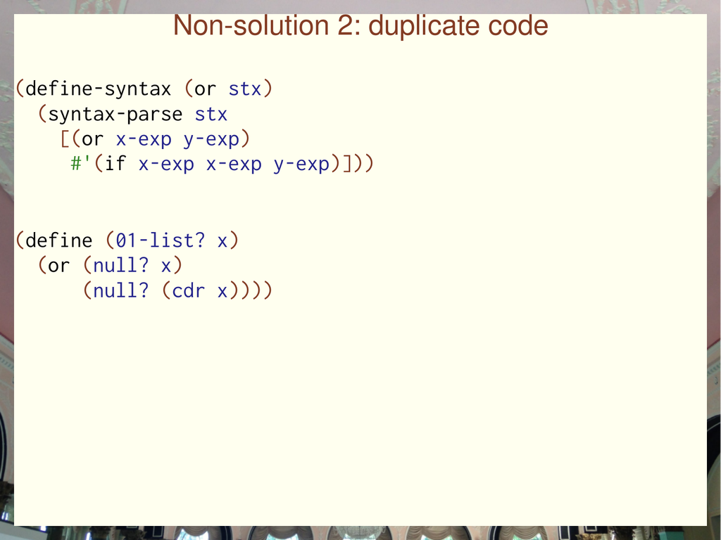

幻灯片 31 · 回到重复代码的问题Slide 31 · Returning to the duplicate-code problem

**幻灯片文字 / Slide text**

```
Non-solution 2: duplicate code
(define (01-list? x)
  (or (null? x)
(null? (cdr x))))
(define-syntax (or stx)
  (syntax-parse stx
  [(or x-exp y-exp)
#'(if x-exp x-exp y-exp)]))
```

那就意味着我在编译期执行一个条件判断，对吧。但因为前面有 #'，所以它是这个宏转换器的结果。我把 or 表达式替换成 if 表达式，因为宏返回的就是它，而这一切都发生在编译期。好，这就是我们的宏。不过，这不是这个问题的好解法，因为它会重复代码。That would mean I'm doing a conditional at compile time right, But because I have the hash tick on the front, that means that's the result of this macro transformer. I'm replacing the ore expression with the if expression because that's what the macro returns, and this is all happening at compile time. Okay, so that's our, that's our macro, and this is not a good solution to the problem because a duplicates code.

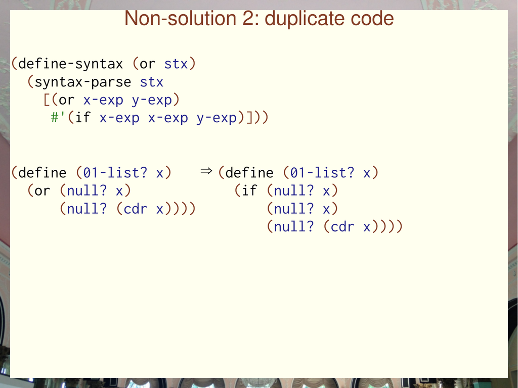

幻灯片 32 · 展开一次后，null? 测试被复制Slide 32 · One expansion duplicates the null? test

**幻灯片文字 / Slide text**

```
Non-solution 2: duplicate code
(define-syntax (or stx)
  (syntax-parse stx
  [(or x-exp y-exp)
#'(if x-exp x-exp y-exp)]))
(define (01-list? x)
  (or (null? x)
(null? (cdr x))))
 ⇒ (define (01-list? x)
  (if (null? x)
(null? x)
(null? (cdr x))))
```

如果看看把宏转换实际应用到那个判断列表长度是否为零或一的函数时会发生什么，就会得到这个结果。x 表达式被复制到了 if 表达式的测试位置和 then 位置。因此，原本只有一个 null? x，现在却有两个了。这很糟，因为如果 or 是嵌套的会怎样？这里有一个 null? x 表达式，然后我进行一步宏转换。So if we look at what happens when we actually apply the macro transformation to the zero and list function, then we get this so the x expression gets duplicated into the test position and the then position of our if expression, And so we have two null question mark x's when we had one originally, So that's bad because what if we had nested oars here I have one no question mark x expression, and then I do one step of macro transformation.

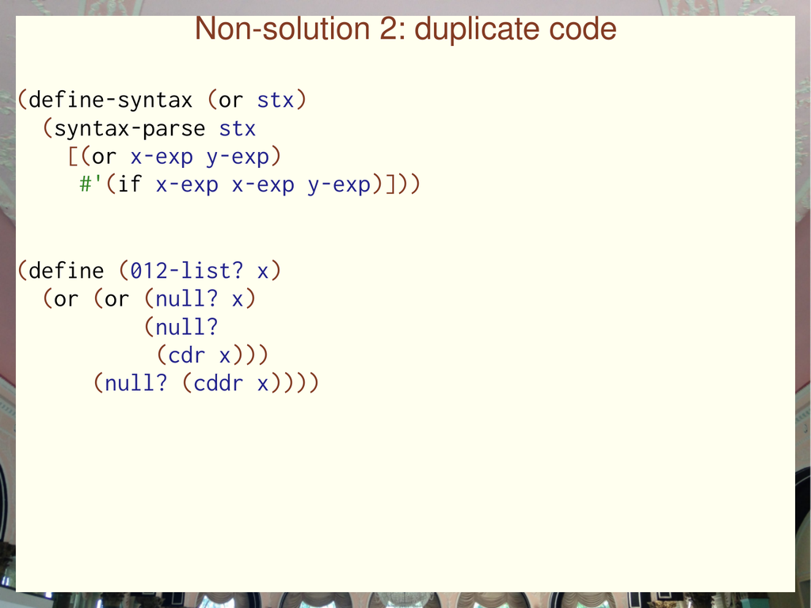

幻灯片 33 · 嵌套的 or 也会被复制Slide 33 · Nested or expressions are duplicated too

**幻灯片文字 / Slide text**

```
Non-solution 2: duplicate code
(define-syntax (or stx)
  (syntax-parse stx
  [(or x-exp y-exp)
#'(if x-exp x-exp y-exp)]))
(define (012-list? x)
  (or (or (null? x)
(null?
(cdr x)))
(null? (cddr x))))
```

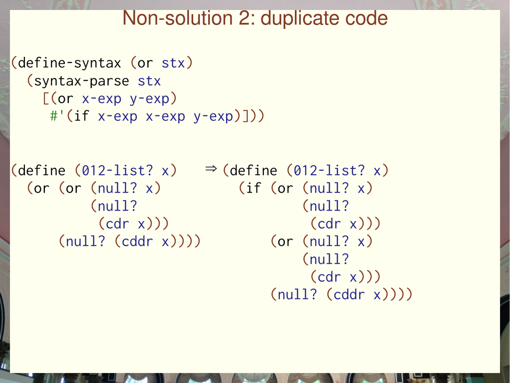

幻灯片 34 · 第一次展开嵌套的 orSlide 34 · The first expansion of a nested or

**幻灯片文字 / Slide text**

```
Non-solution 2: duplicate code
(define-syntax (or stx)
  (syntax-parse stx
  [(or x-exp y-exp)
#'(if x-exp x-exp y-exp)]))
(define (012-list? x)
  (or (or (null? x)
(null?
(cdr x)))
(null? (cddr x))))
 ⇒ (define (012-list? x)
  (if (or (null? x)
(null?
(cdr x)))
(or (null? x)
(null?
(cdr x)))
(null? (cddr x))))
```

现在有两个了，而且还有两个 or。然后就有四个。你们看，如果再嵌套一层，可以想象接下来会发生什么。所以，在重复代码时，展开结果的大小一般可能随程序大小呈指数增长，而编译器会被它撑死。所以这样很糟。Now I have two of them and two more ores, and I now I have four of them, and you see if I nest it one more time. you can imagine what's going to happen. and so this you know the size of the expansion. When you duplicate code, can the general go grow exponentially in the size of the program, and your compiler is going to choke on that so that's bad.

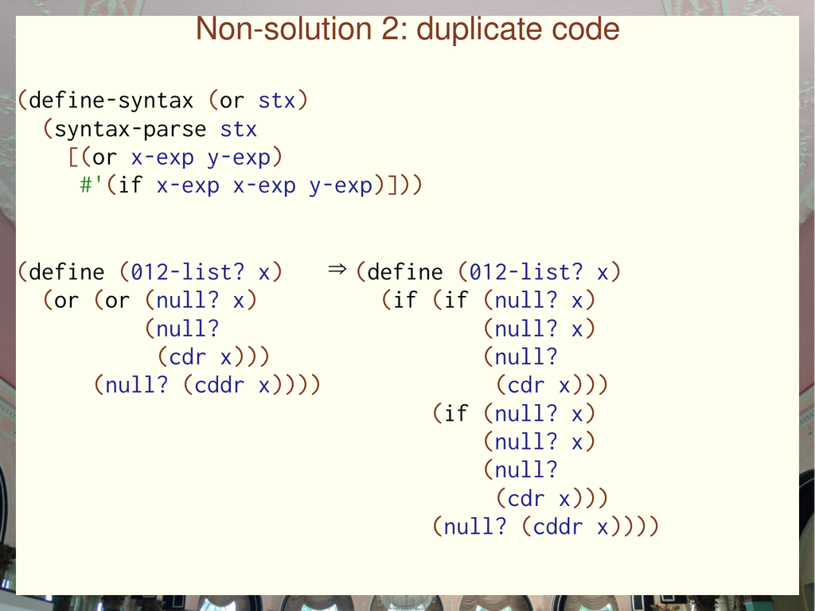

幻灯片 35 · 继续展开，重复代码进一步增长Slide 35 · Further expansion grows the duplicated code

**幻灯片文字 / Slide text**

```
Non-solution 2: duplicate code
(define-syntax (or stx)
  (syntax-parse stx
  [(or x-exp y-exp)
#'(if x-exp x-exp y-exp)]))
(define (012-list? x)
  (or (or (null? x)
(null?
(cdr x)))
(null? (cddr x))))
 ⇒ (define (012-list? x)
  (if (if (null? x)
(null? x)
(null?
(cdr x)))
(if (null? x)
(null? x)
(null?
(cdr x)))
(null? (cddr x))))
```

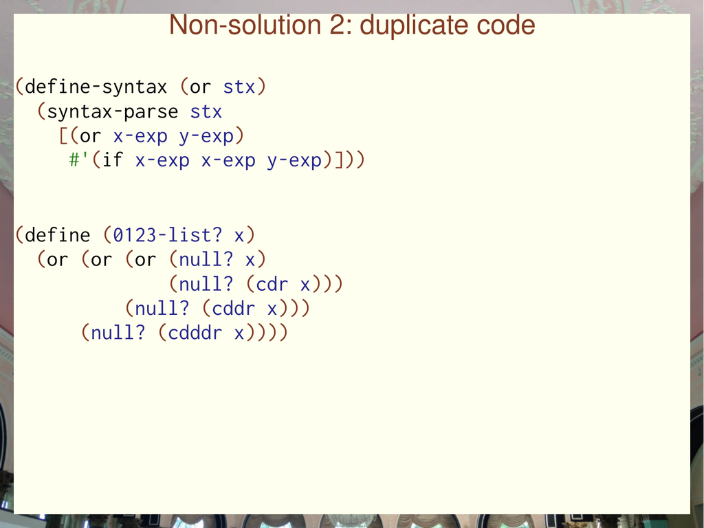

幻灯片 36 · 增加一层嵌套会加剧指数级膨胀Slide 36 · Another nesting level worsens the exponential growth

**幻灯片文字 / Slide text**

```
Non-solution 2: duplicate code
(define-syntax (or stx)
  (syntax-parse stx
  [(or x-exp y-exp)
#'(if x-exp x-exp y-exp)]))
(define (0123-list? x)
  (or (or (or (null? x)
(null? (cdr x)))
(null? (cddr x)))
(null? (cdddr x))))
```

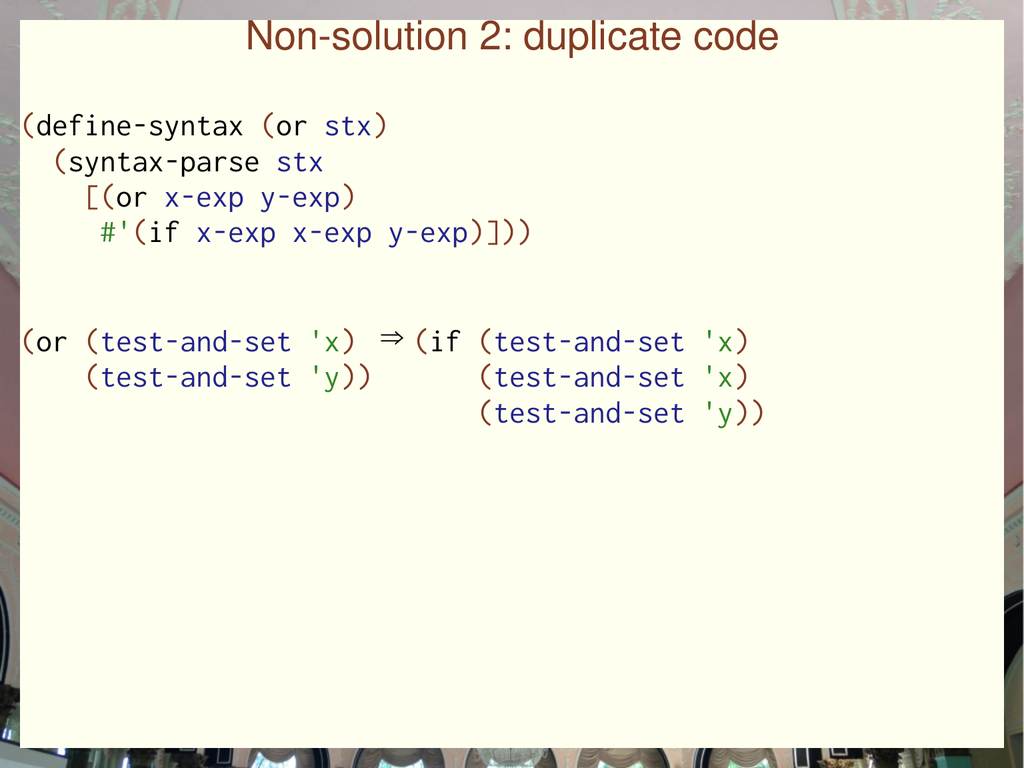

幻灯片 37 · 复制 test-and-set 还会重复副作用Slide 37 · Duplicating test-and-set also duplicates effects

**幻灯片文字 / Slide text**

```
Non-solution 2: duplicate code
(define-syntax (or stx)
  (syntax-parse stx
  [(or x-exp y-exp)
#'(if x-exp x-exp y-exp)]))
(or (test-and-set 'x)
(test-and-set 'y))
 ⇒ (if (test-and-set 'x)
(test-and-set 'x)
(test-and-set 'y))
```

这很糟，实际上还不止如此，因为还有状态。test-and-set 是一种底层原语，可以用来实现同步，比如锁、信号量之类的东西。它所做的是检查 X 是否已经被置位。如果 X 已被置位，就返回假；如果 X 没有被置位——X 就像内存中的某个位置——如果 X 没被置位，就把它置位，并返回真。This is bad, it's actually worse than that though, Because of state test and set is like this low level primitive you can use to implement synchronization, like locks and semaphores and things like that, and what it what it does is It checks to see if X is set and if X is set, it returns false, and if x is not set so like XSM location in memory, If X is not set, then it sets it and returns true.

所以，如果重复那个表达式，它就会始终为真，而你那个初步的锁实现就不会按预期工作，对吧。好，因此重复代码就是不好。好，我们知道如何避免重复代码：使用局部变量，对吧。And so, if you duplicate that expression, then it's always going to be true, and you sort of your little proto lock implementation is not going to be doing what you want it to do. right. So okay, so duplication of code is just bad all right. Okay, So we know how to avoid duplicating code. We use local variables right.

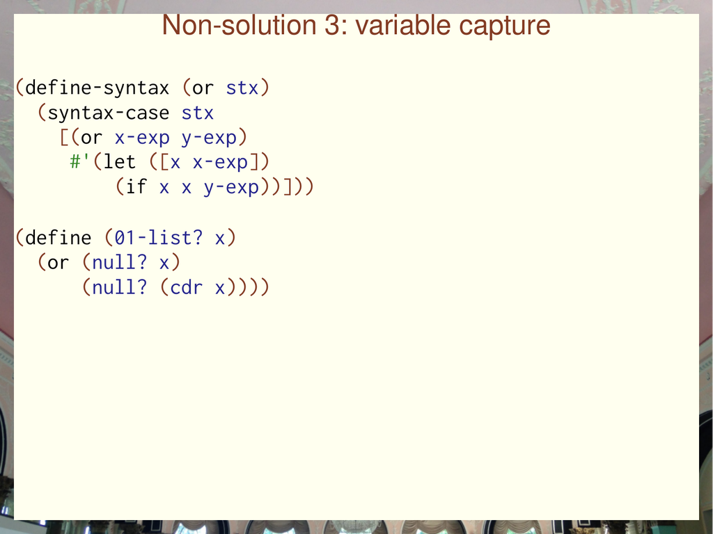

幻灯片 38 · 用 let 保存第一次求值的结果Slide 38 · Use let to save the result of the first evaluation

**幻灯片文字 / Slide text**

```
Non-solution 3: variable capture
(define-syntax (or stx)
  (syntax-case stx
  [(or x-exp y-exp)
#'(let ([x x-exp])
  (if x x y-exp))]))
(define (01-list? x)
  (or (null? x)
(null? (cdr x))))
```

只要把 x 表达式的结果绑定到某个变量 x，然后引用那个变量两次就行了。现在情况好多了，因为至少不会重复副作用，也不会因为展开时产生荒唐的大量代码而把编译器撑死。不过，我们来看看它会怎么转换。You just bind the result of the x expression to some variable x and then you can refer to the variable twice And now we're in good shape because well, at least we don't have the we're not duplicating the effect. We're not going to cause the compiler to choke because we're not sort of growing ridiculous amounts of code in the expansion. But so let's look at see how this transforms.

## 把作用域改为宿主编程语言的作用域Changing the scope to the host programming language

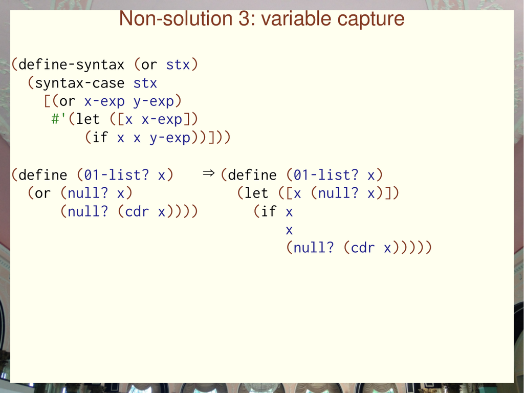

幻灯片 39 · 错误方案三：新引入的 x 捕获原程序中的 xSlide 39 · Non-solution 3: the introduced x captures an original x

**幻灯片文字 / Slide text**

```
Non-solution 3: variable capture
(define-syntax (or stx)
  (syntax-case stx
  [(or x-exp y-exp)
#'(let ([x x-exp])
  (if x x y-exp))]))
(define (01-list? x)
  (or (null? x)
(null? (cdr x))))
 ⇒ (define (01-list? x)
  (let ([x (null? x)])
  (if x
x
(null? (cdr x)))))
```

如果有这个判断列表长度是否为零或一的函数，而它不巧也用了变量名 x，那么我们就有两个 x，它们会彼此冲突。因此，如果用一个只有一个元素的列表调用这个函数，它本该返回真，却会崩溃，报错说给 cdr 传入了假值。So if I have my zero one list function, which unfortunately also happened to use the variable name x in it, then I've got sort of two x's and they're going to collide with each other. So if I call the zero one list function on a list with one element in it, it's supposed to return true, and instead it crashes with could or given false.

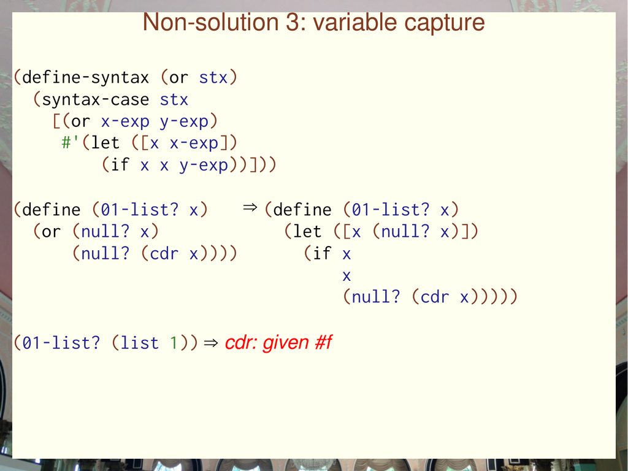

幻灯片 40 · 变量捕获导致 cdr 收到 #fSlide 40 · Variable capture makes cdr receive #f

**幻灯片文字 / Slide text**

```
Non-solution 3: variable capture
(define-syntax (or stx)
  (syntax-case stx
  [(or x-exp y-exp)
#'(let ([x x-exp])
  (if x x y-exp))]))
(define (01-list? x)
  (or (null? x)
(null? (cdr x))))
 ⇒ (define (01-list? x)
  (let ([x (null? x)])
  (if x
x
(null? (cdr x)))))
(01-list? (list 1)) ⇒ cdr: given #f
```

唯一使用 cdr 的地方就在右下角，那里的 cdr x。原程序中的那个 x 指向形参，也就是传给这个判断列表长度是否为零或一的函数的参数。但经过宏展开之后，它指向的却是新引入的这个临时变量。这很糟，也不是我们想要的。不过，这个例子的问题并不在宏本身。The only use of kutter is that one in the bottom right there, so he could have x there That x is in the original program. The x is referring to the parameter, It's the argument to the zero in this function, but in after the macro expansion step, it's referring to this temporary variable that got introduced. So that's bad, and that's not what we wanted. now. The problem in this case is not with the macro.

问题是宏系统没有尊重宿主编程语言的一部分，没有尊重作用域，也就是宿主编程语言中变量的作用域概念。因此，我们想要一种叫作卫生性的东西。The problem is that the macro system is not respecting a part of the post programming language, it's not respecting the scope, the notion of scope, the variables in the host programming language. So what we want is something called hygiene.

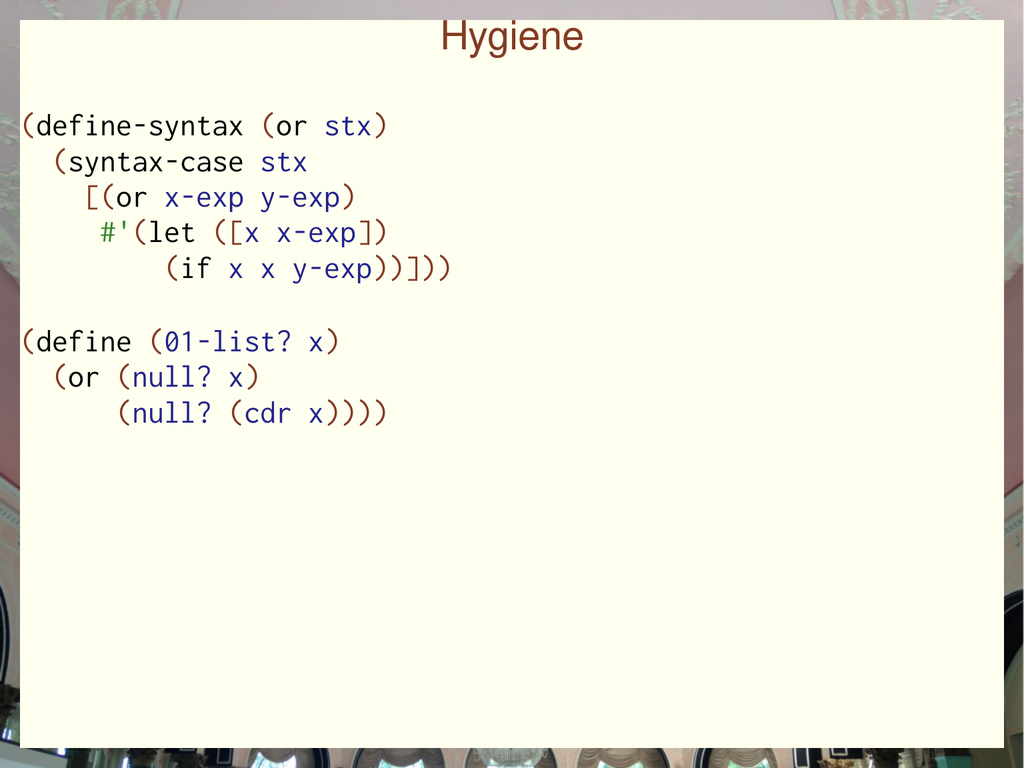

幻灯片 41 · 卫生性：让宏系统尊重语言的作用域Slide 41 · Hygiene: make the macro system respect language scope

**幻灯片文字 / Slide text**

```
Hygiene
(define-syntax (or stx)
  (syntax-case stx
  [(or x-exp y-exp)
#'(let ([x x-exp])
  (if x x y-exp))]))
(define (01-list? x)
  (or (null? x)
(null? (cdr x))))
```

好，现在，给大家一点历史背景：在宏技术上，我们现在赶上了 1986 年。好，等我用接下来的两三张幻灯片讲完卫生性，具体几张无所谓。好，卫生性的工作方式是，你说，这是原始程序。Okay, and so now I just to put this in some context, we are now caught up with 1986. Okay, in macro technology all right after I explain how you in the next two slides or three slides or whatever all right. Okay, So the way hygiene works is you say, Oh, this is the original program.

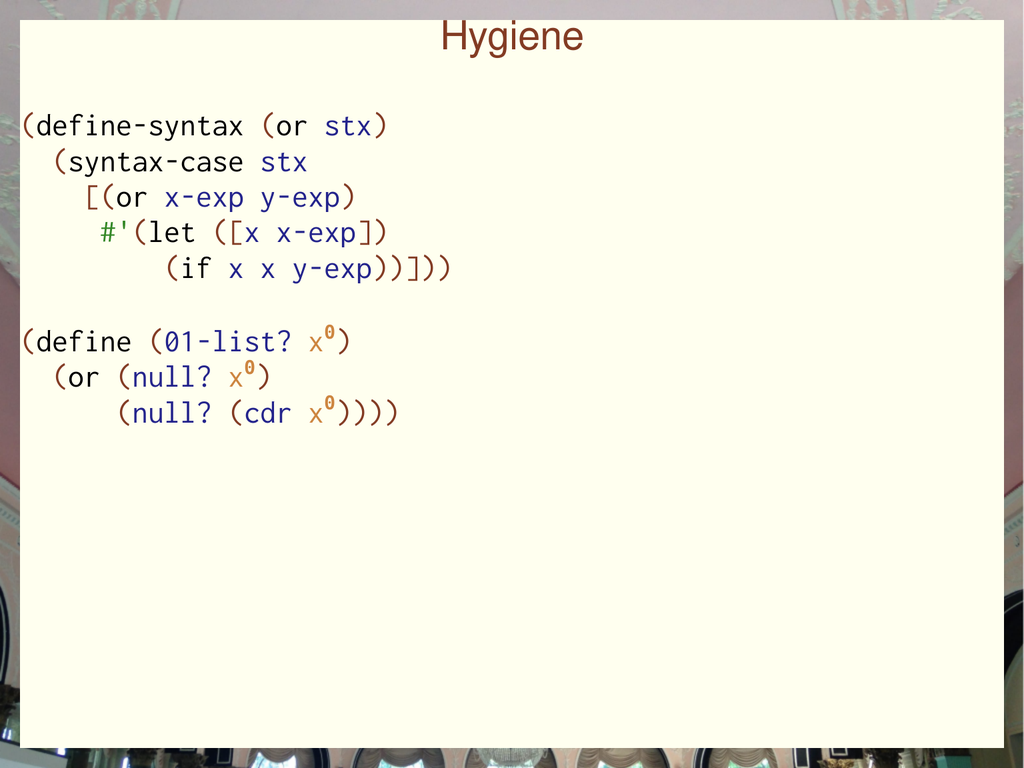

幻灯片 42 · 为原程序中的变量标记展开阶段 0Slide 42 · Mark original variables with expansion step 0

**幻灯片文字 / Slide text**

```
Hygiene
(define-syntax (or stx)
  (syntax-case stx
  [(or x-exp y-exp)
#'(let ([x x-exp])
  (if x x y-exp))]))
(define (01-list? x0)
  (or (null? x0)
(null? (cdr x0))))
```

我要给其中所有变量加上标记，表示它们处在宏展开的第零步，也就是在宏展开开始之前就已经存在了。随后，每进行一步宏转换，凡是这一步引入的变量，都会带上与这一步对应的编号，或者对应的颜色。I will put a marker on all the variables in it to indicate that they are in the zeroeth step of macro expansion. They exist before macro expansion started happening, and then whenever I do a step of macro transformation, any variables that are introduced in that step, they will get a number associated with whatever step they are on or a color associated with it.

## 修改语言的语法规则Changing the language's syntax rules

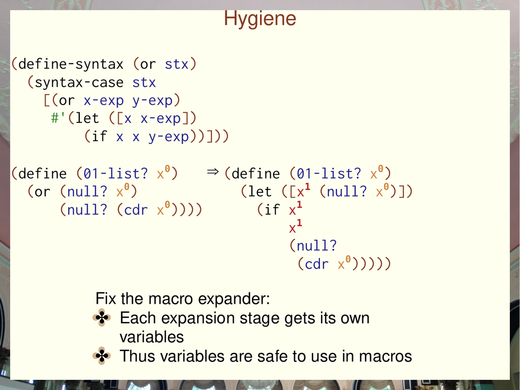

幻灯片 43 · 宏引入的 x¹ 与原来的 x⁰ 是不同绑定Slide 43 · The introduced x¹ and original x⁰ are different bindings

**幻灯片文字 / Slide text**

```
Hygiene
(define-syntax (or stx)
  (syntax-case stx
  [(or x-exp y-exp)
#'(let ([x x-exp])
  (if x x y-exp))]))
(define (01-list? x0)
  (or (null? x0)
(null? (cdr x0))))
 ⇒ (define (01-list? x0)
  (let ([x1 (null? x0)])
  (if x1
x1
(null?
(cdr x0)))))
Fix the macro expander:
✤
✤Each expansion stage gets its own
variables
✤
✤Thus variables are safe to use in macros
```

所以，作为那个判断列表长度是否为零或一的函数的形参的 x，都带着 0；由宏展开引入的 x，也就是第一步宏展开引入的 x，都带着 1。编译器知道，带 0 和带 1 的这些 x，本质上应该算不同的 x。好，现在这个程序，你知道，只要使用一个好的、尊重作用域的宏系统，这个宏就是正确的。所以，重要的是，回顾一下。So the x's that are the parameter to the 0 1 list function have zero and the x's that were introduced by the macro expansions. The first macro expansion step have a one, and the compiler knows the zeros and ones that sort of count morally as different x's. Okay, So this program now you know this macro is correct If you use a good macro system, one that respects the scope, so it's important recap.

我们希望宏系统尊重编程语言在解析层面的结构，希望宏系统尊重编程语言在表达式层面的结构，也希望它尊重编程语言在变量层面的结构。你必须能够做到所有这些，才能有一个坚实的基础，用来构建真正的编程语言。你不想非得……We want to respect the parsing level structure of the programming language in the macro system, We want to respect the expression level structure of the programming language in our macro system, and we want to respect the variable level structure of the programming language. You need to be able to do all these things, so you have this firm foundation on which to be able to build real programming languages, you don't want to have to like.

## 第 1 章：理解编程语言中的作用域Ch 1: Understanding Scope in Programming Languages

记得在标识符末尾加上井号，对吧。这样做很容易出错。事实上，这里面还有更多可以说的。加井号其实算不上多大的麻烦，但在某些情况下，你既需要加上井号，又需要不加井号，对吧。Remember to put hashes on the ends of your identifiers. Right, it's easy to make mistakes if you do that, and in fact there's more to be said there. Putting hash is not actually that big a deal, but in some situations you don't you, you both need to put and not put the hash right.

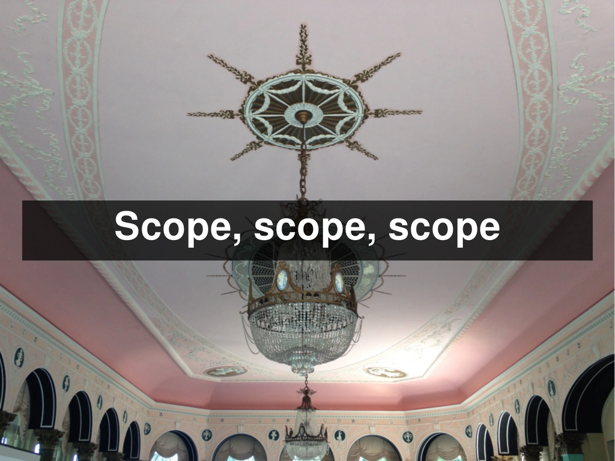

幻灯片 44 · 作用域，作用域，还是作用域Slide 44 · Scope, scope, scope

**幻灯片文字 / Slide text**

```
Scope, scope, scope
```

好，知道我在说什么的人自然知道。好，不过，现在我想再往前走一点，谈谈当编程语言、宏系统真正理解作用域时，你能利用它构建什么好东西。我会通过一个常见缺陷，一个常见的……Okay, so those you know what I'm talking about you know Okay, But so I want to I want to go a little further now and to talk about how when you have scope sort of really understood by the programming language by the macro system that you can build some good stuff using it, and I'm going to do that by looking at kind of a common flaw, a common.

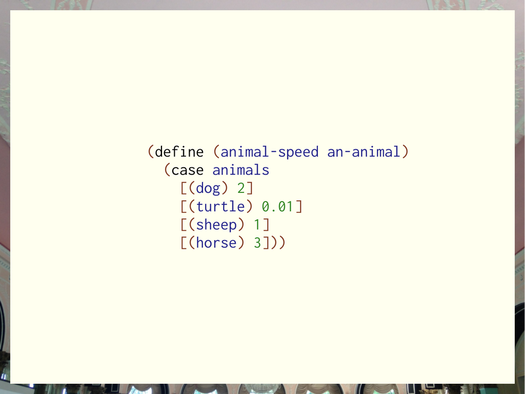

幻灯片 45 · 用符号表示动物枚举Slide 45 · Representing an animal enumeration with symbols

**幻灯片文字 / Slide text**

```
(define (animal-speed an-animal)
  (case animals
  [(dog) 2]
  [(turtle) 0.01]
  [(sheep) 1]
  [(horse) 3]))
```

我也不知道该怎么说，编程语言中常见的一种坏情况来说明。比如，一般的 Lisp、Scheme 家族里没有枚举操作，没有枚举，所以你会用符号来代替。如果你不熟悉这种东西，那就想成字符串，这里和用字符串是一样的。基本上，我脑子里有这么个概念：有四种动物……I don't know what I don't know what bad thing that happens in programming languages you know, like in the in the general lisp scheme family Where you don't have an enum operation, you don't have enums, so what you do is you use symbols instead of, And if you're not familiar with that sort of thing and then strings, it's the same thing as using strings here, so basically I have I have in my mind the notion that there are four kinds of animals.

是我在这个程序里关心的。我用符号、字符串或者其他什么东西来表示这四种不同的动物，因为我的编程语言里没有内置枚举这种概念。I'm interested in with this program and I'm using symbols or strings or whatever to represent those four different because I don't have a notion of an enum thing built into my programming language.

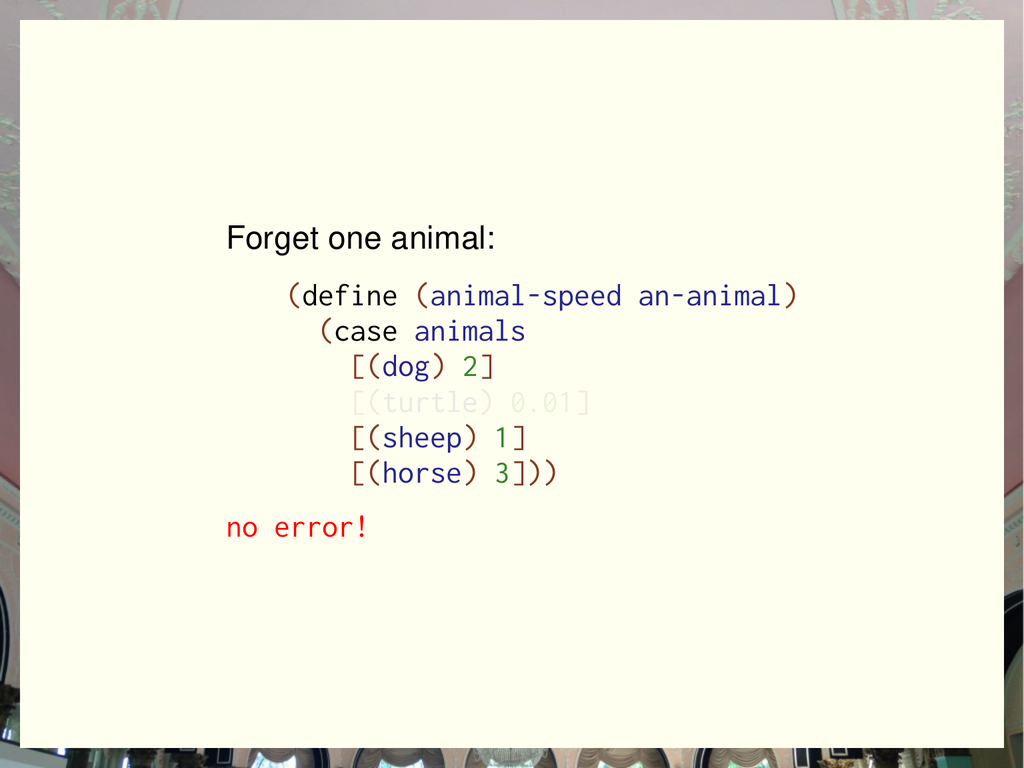

幻灯片 46 · 漏掉一种动物，普通 case 却不会报告错误Slide 46 · An ordinary case does not report a missing animal

**幻灯片文字 / Slide text**

```
Forget one animal:
(define (animal-speed an-animal)
  (case animals
  [(dog) 2]
  [(turtle) 0.01]
  [(sheep) 1]
  [(horse) 3]))
no error!
```

这个例子里有狗、乌龟、绵羊和马。我心里认为可能的……可能的动物就是这些。如果漏掉其中一种，编程语言不会抱怨；如果测试套件不够好，我就发现不了。其实情况还会更糟，因为你当然不可能永远不动它，对吧。So in this case, there's dogs, turtles, sheeps and horses, and that's how I think about what the possible character possible animals are, and if I forget one of them, then the programming language doesn't complain at me and if I don't have a good enough test suite, I don't notice or it's actually kind of worse than that because, of course, you're never going to leave it alone right.

## 动物分支宏的案例The Case of the Animal Case Macro

你的程序，要么不断演化和变化，要么就死了。所以，我很可能会修改枚举，添加一个新项，或者删掉一项，诸如此类。我希望能够让编译器真正帮我找出程序中需要修改的地方。Your programs either the programs either evolve and change, or they're dead, and so probably I'm going to change and add a new thing to my enum or remove one or something like that, and I want to be able to help the compiler to actually help me find the places where I need to modify my program all right.

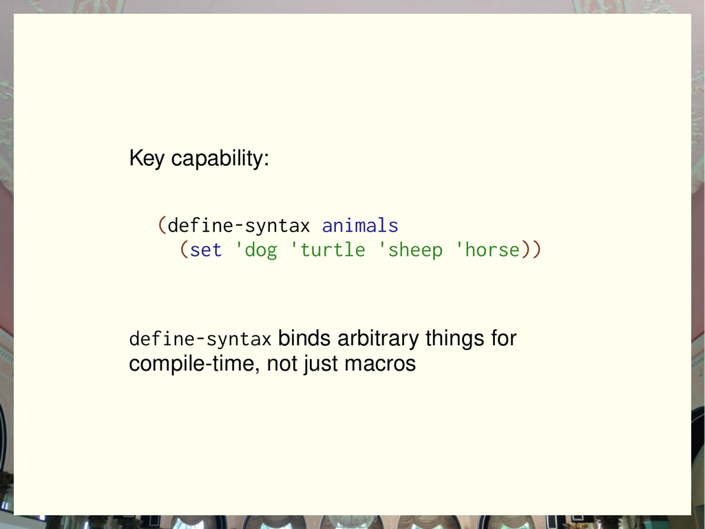

幻灯片 47 · define-syntax 也能把集合等任意值绑定在编译期Slide 47 · define-syntax can bind arbitrary values, including sets, for compile time

**幻灯片文字 / Slide text**

```
Key capability:
(define-syntax animals
  (set 'dog 'turtle 'sheep 'horse))
define-syntax binds arbitrary things for
compile-time, not just macros
```

所以，我们现在回到 define-syntax。这次我使用 define-syntax，在编译期把变量 animals 绑定到一个集合。这是一个符号集合，包含我目前认为应该作为动物名称的所有符号。这个定义有意思的地方在于，我并没有定义宏，只是在定义一个编译期对我有用的东西。So so we'll return to this defined syntax guy now and now I'm using define syntax to bind at compile time the variable animals to a set and it's a set of all the symbols that currently I think of as what the animal name should be. And what's interesting about this definition is that I'm not defining a macro, I'm just defining a thing which will be useful to me at compile time.

宏是一个在编译期对我有用、宏展开器知道如何处理的函数。而这里，我只是在定义一个编译期对我有用的变量，因此可以在编译期查找它。要做到这一点，还需要一个部件。A macro is a function that's useful to me to compile time that the macro expander knows how to work with. Here. I'm just defining a variable that's useful to me at compile time, and so I can look it up at compile time, and so you need one more piece to be able to do that.

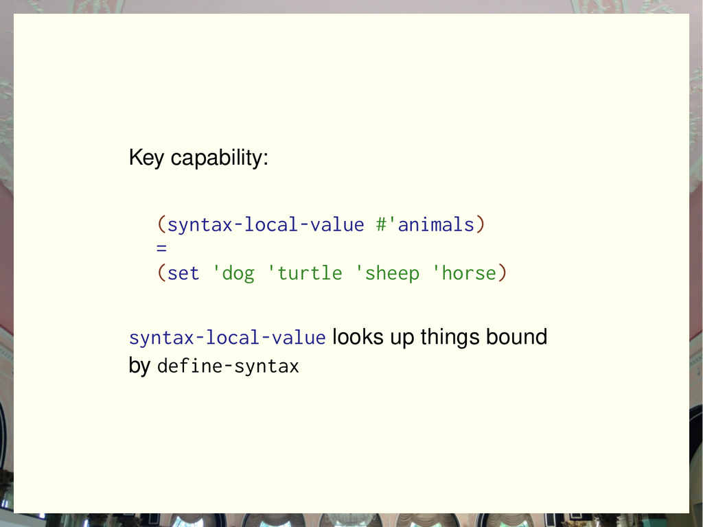

幻灯片 48 · syntax-local-value 按词法作用域查找编译期绑定Slide 48 · syntax-local-value looks up compile-time bindings using lexical scope

**幻灯片文字 / Slide text**

```
Key capability:
(syntax-local-value #'animals)
=
(set 'dog 'turtle 'sheep 'horse)
syntax-local-value looks up things bound
by define-syntax
```

如果调用 syntax-local-value，传给它一个表达式，这个表达式应该是一个变量，那么它就会查出那个变量绑定到了什么。你可以在编译期用它查找 animals 的绑定。这样做，就会得到那个集合，同一个集合。If you say syntax local value, you give it an expression that should, and that expression should be a variable, then it will look up what that variable is bound to, and you can use this at compile time to look up what animals is bound to. so, and if you do this, then you'll get back that set that same set.

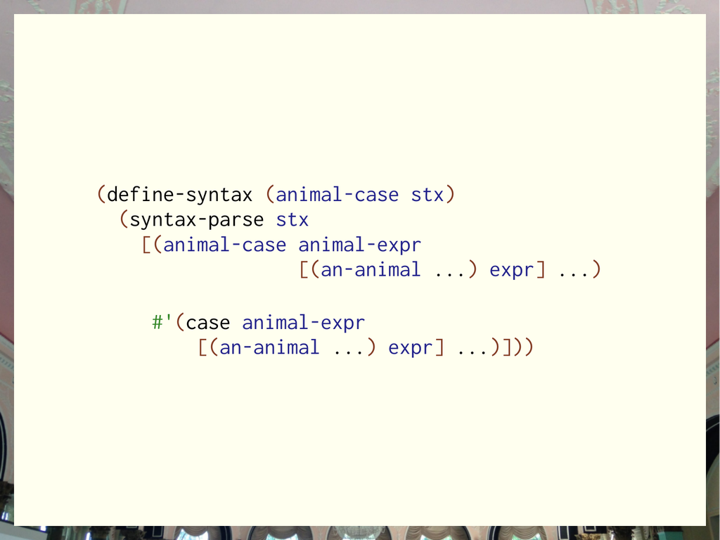

幻灯片 49 · animal-case：先把模式直接转换为 caseSlide 49 · animal-case: first translate the pattern directly into case

**幻灯片文字 / Slide text**

```
(define-syntax (animal-case stx)
  (syntax-parse stx
  [(animal-case animal-expr
[(an-animal ...) expr] ...)
#'(case animal-expr
  [(an-animal ...) expr] ...)]))
```

好，现在我们可以把它和定义宏的能力结合起来，真正加上一些检查。这就是 animal-case 宏的定义。它仍然使用 syntax-parse，目前还没有对 animals 做什么有意思的事情，只是直接展开成 case 表达式。所以，这里说的是，一个 animal-case 表达式应该包含一个动物表达式，后面跟着一系列分支。Okay, and now we can put this together with the ability to define macros to actually put some checking in. So, so here is the definition of an animal case macro. Okay, and it's still using syntax parse, and it's actually not doing anything interesting with animals, yet it's just expanding directly into the case expression. so what this is saying is an animal case expression should have an animal expression and then followed by a bunch of cases.

省略号表示，前面的东西可以重复任意多次。因此，可以有任意多个不同的分支，而每个分支里又可以有任意多个动物。它只是展开成 case，因此仍然使用之前那个构造来完成 case……The ellipsis means you can repeat the thing that comes before as many times as you like, so we can have as many different cases, and each case can have as many animals as you want inside them, and it just expands into the case, so it's using the same construct we were using before to do the case.

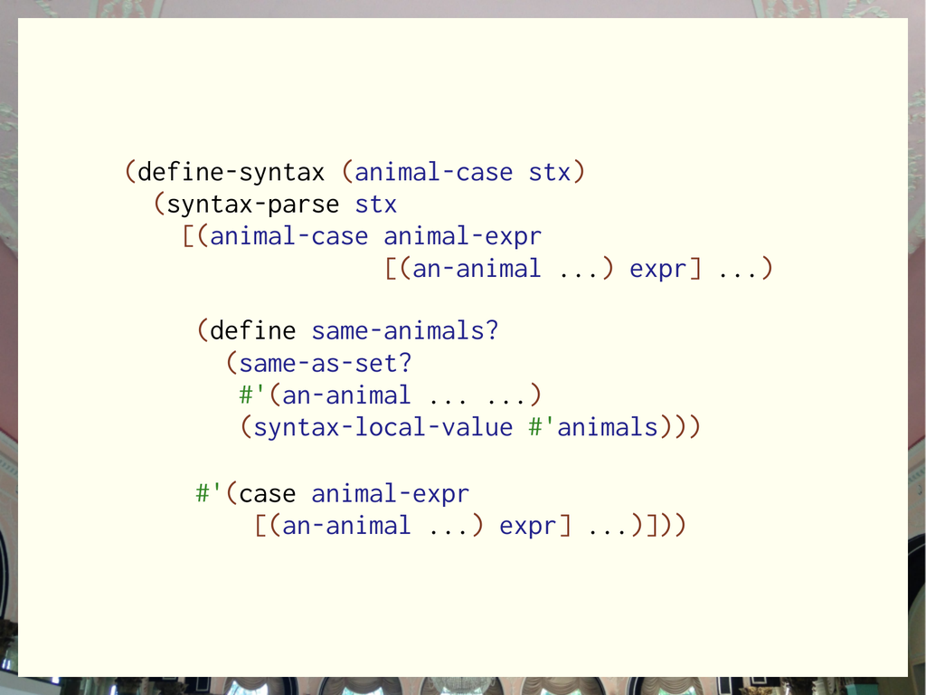

幻灯片 50 · 在编译期比较出现的动物集合与已声明集合Slide 50 · Compare the used and declared animal sets at compile time

**幻灯片文字 / Slide text**

```
(define-syntax (animal-case stx)
  (syntax-parse stx
  [(animal-case animal-expr
[(an-animal ...) expr] ...)
(define same-animals?
  (same-as-set?
#'(an-animal ... ...)
(syntax-local-value #'animals)))
#'(case animal-expr
  [(an-animal ...) expr] ...)]))
```

分派。我们真正想做的是，在上面再加一层检查，告诉我们里面的动物集合对不对。好，因为这个宏在编译期运行，所以我们可以直接在编译期运行代码。我写了一个名叫 same-as-set? 的小函数，这里没有展示它。Dispatch, and what we really want to do is layer in some additional checking that tells us whether or not we've got the right set of animals in there. Okay, So we can just run stuff at compile time because this macro is run at compile time, and so what we can do is I've written a little function called same as set which I'm not showing you here.

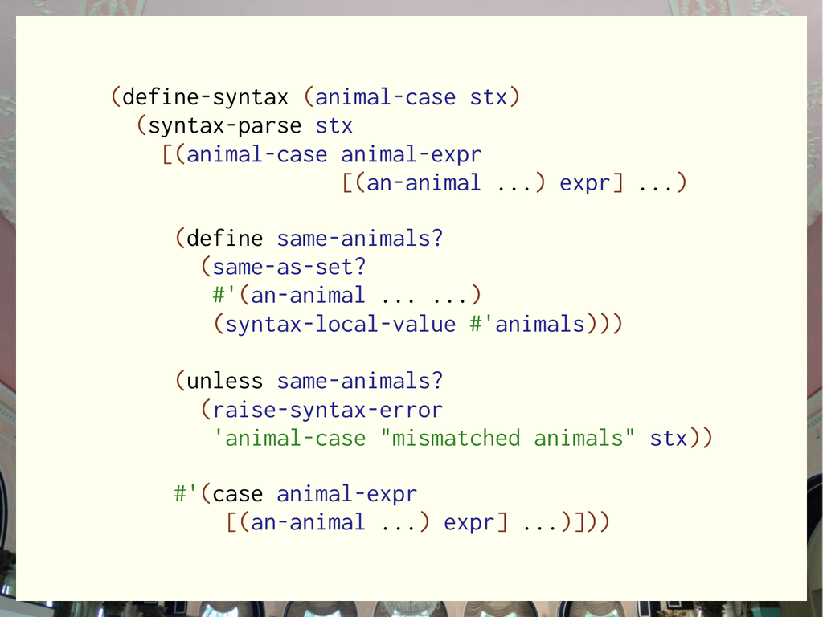

幻灯片 51 · 集合不匹配时，raise-syntax-error 报告源代码位置Slide 51 · Use raise-syntax-error with source locations when the sets differ

**幻灯片文字 / Slide text**

```
(define-syntax (animal-case stx)
  (syntax-parse stx
  [(animal-case animal-expr
[(an-animal ...) expr] ...)
(define same-animals?
  (same-as-set?
#'(an-animal ... ...)
(syntax-local-value #'animals)))
(unless same-animals?
  (raise-syntax-error
'animal-case "mismatched animals" stx))
#'(case animal-expr
  [(an-animal ...) expr] ...)]))
```

基本上，我给它的一个参数，是一棵对应于这个表达式中提到的所有动物的树；另一个参数是 syntax-local-value #'animals。我们已经知道，它只会查找当前词法上下文中的 animals 是什么，返回之前的那个集合。然后，same-as-set? 会根据两者作为集合来看是否相同，返回真或假。好，接着我们就能检查这个布尔值是不是真。如果是假，就调用一个名叫 raise-syntax-error 的函数。raise-syntax-error 接收的参数是……But basically, I give it as one argument the tree that corresponds to all of the animals that are mentioned in this expression, and I give it the other argument syntax local value hash quote animals, which, as we know, is going to just look up what animals is in the current lexical context and return to that set that we had there, and then same as that will return you the true or false if they're the same when viewed as a set okay, and then what we can do is We can just check and see if that boolean is true or not, and if it's false, then we'll call this function called raise syntax error and what race syntax error takes is.

## 改用枚举语法，以获得更好的错误消息并细化代码中的检查Changing to enum syntax for better error messages and refining checks in the code

前两个参数基本上是一些要放进错误消息里的文本信息。有意思的是第三个参数。raise-syntax-error 会查看它。传入 animal-case 宏的树带有一些元数据，例如行号和列号信息。它可以使用这些信息，直接给出错误消息。The first two arguments are basically some information about you know text to put into the error message, and the interesting one is that third argument, and what that race syntax error does Is It looks at that, and there's like metadata associated with the tree that got passed into the animal case macro that has things like line and column information in it, and it can use that to give an error message directly.

比如在源文本中高亮正确的位置；或者，如果你在终端里运行，就直接打印行号、列号等信息。好，也许我们不想只有 animals 这一种枚举，可能还想要更多枚举。因此，也许应该有个 define-enum，采用一种漂亮的枚举语法，并给我们一个统一的控制点，这样就有可能在 enum-case 宏里提供更好的错误消息和更细致的检查。You know highlighting the right spot in the in the source text or just to print out line column information if you're running up to the terminal or whatever. Okay, So we don't maybe we want to have more enums than just animals, so maybe we should have defined enum, which uses a nice syntax for enums and gives us a single point of control so that we can have maybe have better error messages and more refined checking in our in our in an enum case macro.

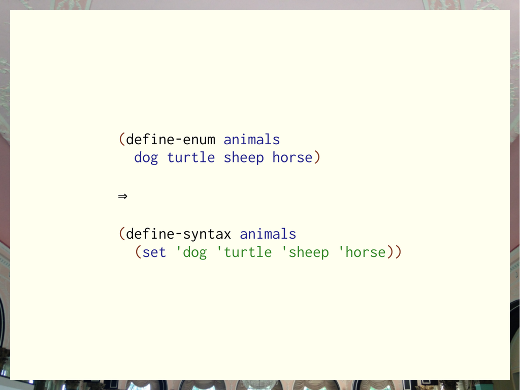

幻灯片 52 · define-enum 展开成一个编译期集合绑定Slide 52 · define-enum expands into a compile-time set binding

**幻灯片文字 / Slide text**

```
(define-enum animals
  dog turtle sheep horse)
⇒
(define-syntax animals
  (set 'dog 'turtle 'sheep 'horse))
```

所以，我们写 define-enum animals。当然，它应该直接展开成 define-syntax，对吧。好，大家现在都跟上宏的工作方式了，因此这是一个很直接的宏。只要把它变成 define-syntax 就行。然后我们就可以把它推广。So we say define enum animals, and of course, that should just expand into defined syntax right, and so that's like okay, So you guys are all up to speed on how macros work, and so that's a That's a straightforward macro. Now you just turn it into define syntax, and then we can generalize.

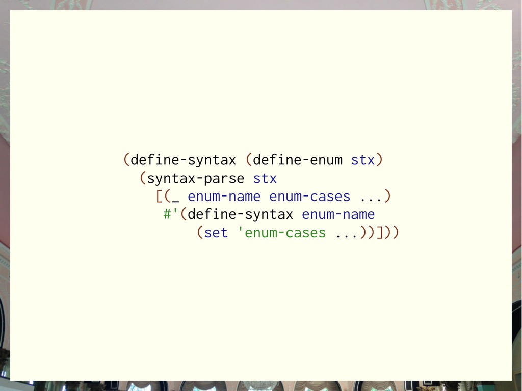

幻灯片 53 · define-enum 本身也是一个简单的宏Slide 53 · define-enum is itself a simple macro

**幻灯片文字 / Slide text**

```
(define-syntax (define-enum stx)
  (syntax-parse stx
  [(_ enum-name enum-cases ...)
#'(define-syntax enum-name
  (set 'enum-cases ...))]))
```

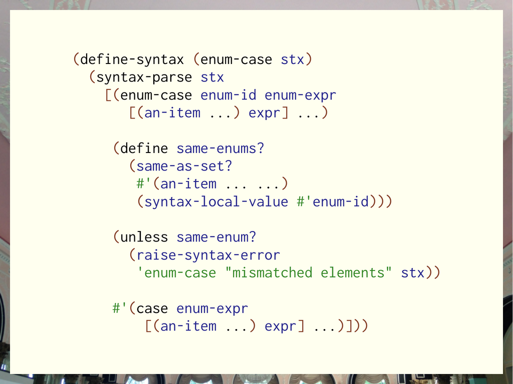

幻灯片 54 · 把 animal-case 推广为 enum-caseSlide 54 · Generalizing animal-case into enum-case

**幻灯片文字 / Slide text**

```
(define-syntax (enum-case stx)
  (syntax-parse stx
  [(enum-case enum-id enum-expr
  [(an-item ...) expr] ...)
(define same-enums?
  (same-as-set?
#'(an-item ... ...)
(syntax-local-value #'enum-id)))
(unless same-enum?
  (raise-syntax-error
'enum-case "mismatched elements" stx))
#'(case enum-expr
  [(an-item ...) expr] ...)]))
```

这段代码和 animal-case 完全一样，只不过把 animal 这个词换成了 enum。另外还有两处变化：除了那个表达式，还必须传入枚举；然后对那个枚举使用 syntax-local-value。由于宏系统对编程语言的理解中内置了作用域的概念，所以这个 syntax-local-value 会取得正确的枚举。因此，你可以在某个局部作用域中声明枚举，它照样会工作。This is the exact same code as animal case, except for the word animal is now replaced with enum, And there are two other changes, namely you have to put in the enum in addition to putting in the expression and then use syntax local value on that enum, and so because scope is baked into the understanding that the macro system has of the programming language, then this syntax local value is going to get the right enum, so you can declare your enum in a local scope somewhere and it will work.

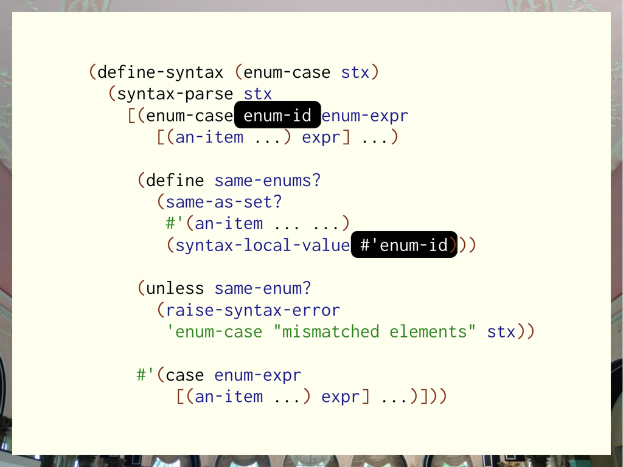

幻灯片 55 · enum-id 的词法上下文决定查找哪个枚举Slide 55 · The lexical context of enum-id determines which enumeration is found

**幻灯片文字 / Slide text**

```
(define-syntax (enum-case stx)
  (syntax-parse stx
  [(enum-case enum-id enum-expr
  [(an-item ...) expr] ...)
(define same-enums?
  (same-as-set?
#'(an-item ... ...)
(syntax-local-value #'enum-id)))
(unless same-enum?
  (raise-syntax-error
'enum-case "mismatched elements" stx))
#'(case enum-expr
  [(an-item ...) expr] ...)]))
```

它会做正确的事情，因为 syntax-local-value 理解编程语言作用域的方式，与宏系统理解作用域的方式相同。好，这比最初那种卫生性概念更一般。不过，如果你是宏程序员，或者这些宏的使用者，只需要认为作用域是正常工作的，就足够理解这个宏里发生的事情了。It will do the right thing because syntax local value understands the scope of the programming language in the same way that the macro system understands the scope. Okay, so this is more general than just the sort of original notion of hygiene. But but if you're thinking about it as a macro programmer or as a user of these macros, you just think scope works, and that's enough to understand what's happening in this macro all right.

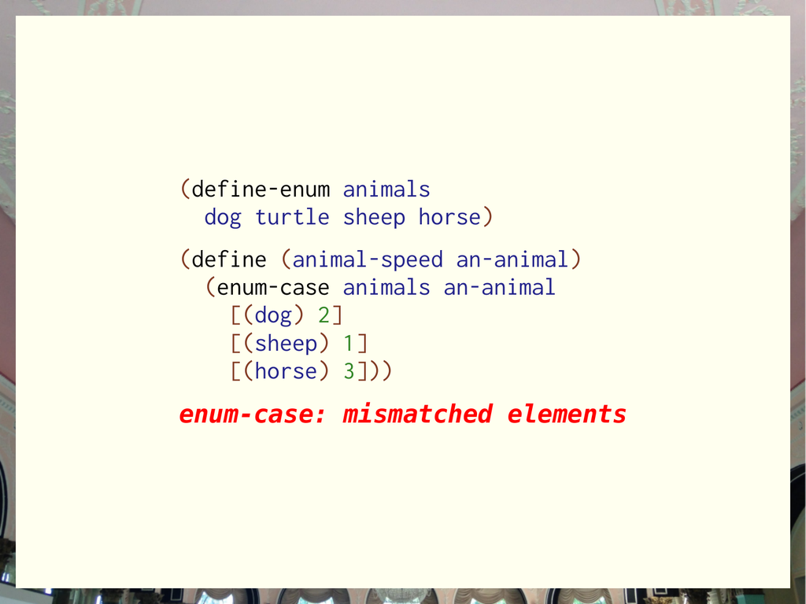

幻灯片 56 · enum-case 在编译期报告缺失的枚举分支Slide 56 · enum-case reports missing enumeration cases at compile time

**幻灯片文字 / Slide text**

```
(define-enum animals
  dog turtle sheep horse)
(define (animal-speed an-animal)
  (enum-case animals an-animal
  [(dog) 2]
  [(sheep) 1]
  [(horse) 3]))
enum-case: mismatched elements
```

所以，代码看起来就是这样。我又漏掉了乌龟这一项。现在我们会得到这个 enum-case 错误，而且带有正确的源代码位置。无论是在 DrRacket、终端还是其他地方运行，所有这些信息都会在错误中打印出来。好。And so here's what the code looks like, and I left out the turtle case again, and now we get this enume case and with the right source location and everything would be printed out in the in the era if we run it in Dr racket or in the terminal or whatever. all right.

好，这就简单介绍了，一个正确尊重其所在编程语言底层结构的宏系统，能够带来的一些好处。而这也让我们赶上了……Okay, So that's That's a little bit about some of the benefits you get of having a macro system that properly respects the underlying structure of the programming language that it's a host to and gets us caught up to.

## 可以吗？May I?

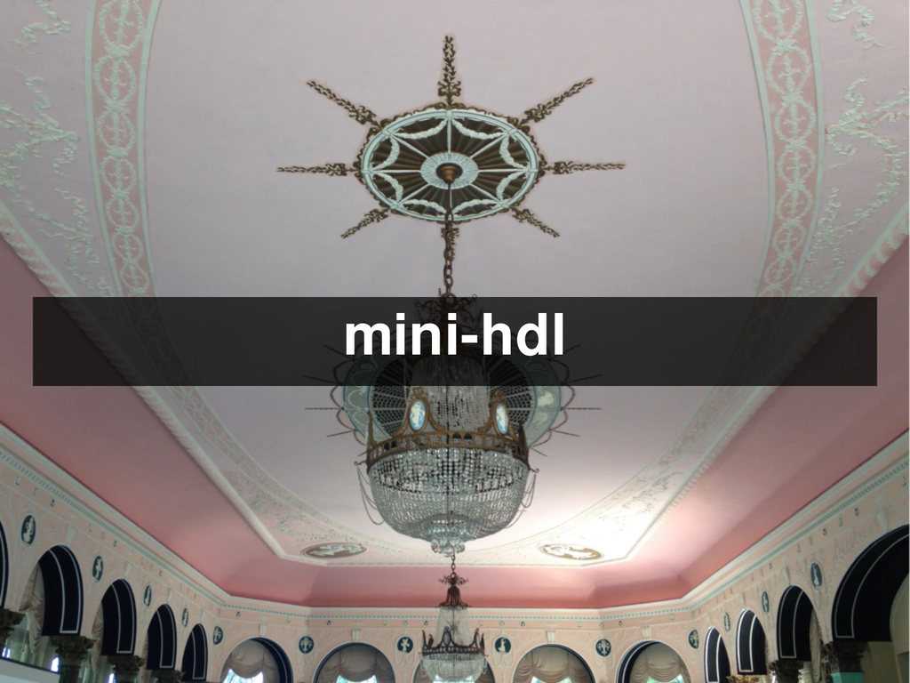

幻灯片 57 · mini-hdl：一个小型硬件描述语言Slide 57 · mini-hdl: a small hardware-description language

**幻灯片文字 / Slide text**

```
mini-hdl
```

也许，我不知道，不确定，宏系统技术在 90 年代末或 2000 年代末的某个时候，我想是 2002 年。不是说那之后有过特别多进展，不过还是有一些。好。那么现在让我花一点时间，展示另一门我为这次演讲实现的编程语言。那是一门迷你硬件描述语言。Maybe I don't know, I'm not sure where somewhere in the late 90 s or late 2000 s of macro system technology in 2002, I think not that there's been a lot since then, but there's some okay all right. So let me take a minute now and show you another programming language that I implemented for this talk. That is a mini hardware description language.

现场演示：六位行波进位加法器，输入 11 与 22Live demo: a six-bit ripple-carry adder with inputs 11 and 22

```
#lang mini-hdl

inputs a5,a4,a3,a2,a1,a0=11;
inputs b5,b4,b3,b2,b1,b0=22;

s0 = a0 ⊕ b0;
c0 = a0 ∧ b0;

s1 = a1 ⊕ b1 ⊕ c0;
c1 = (a1 ∧ b1) ∨ (c0 ∧ (a1 ⊕ b1));

s2 = a2 ⊕ b2 ⊕ c1;
c2 = (a2 ∧ b2) ∨ (c1 ∧ (a2 ⊕ b2));

s3 = a3 ⊕ b3 ⊕ c2;
c3 = (a3 ∧ b3) ∨ (c2 ∧ (a3 ⊕ b3));

s4 = a4 ⊕ b4 ⊕ c3;
c4 = (a4 ∧ b4) ∨ (c3 ∧ (a4 ⊕ b4));

s5 = a5 ⊕ b5 ⊕ c4;
c5 = (a5 ∧ b5) ∨ (c4 ∧ (a5 ⊕ b5));

showint(c5,s5,s4,s3,s2,s1,s0);
```

好，我先给大家看这个程序，然后快速浏览一下这门编程语言的实现，让你们体会做这样一件事需要多少代码。好，mini HDL 主要关注组合逻辑。你知道，这里没有环路，也没有诸如此类的东西。Okay, and i'll just show you this program, and then i'll give you kind of a flyby of the implementation of the programming language, so you get a sense of how much code it takes to do something. Okay, So mini HDL is It's really focused on, like the combinatory logic, You know, there's no, there's no cycles or anything like that happening here.

不过，如果我……你写 inputs，再放上一系列变量，它们就是电路的输入。然后，这里的等于 11 表示，取出 11，把它看成一个二进制补码表示的二进制数，再把 a0、a1、a2 等初始化成与那些 1 和 0 对应的布尔值。对 b 里的 22 也做同样的事。然后做一些操作，接着是 showint，你把那些 1 和 0，也就是对应的布尔值传给它……But so if I, if I, if I say you say inputs and you put a bunch of variables, this is the inputs to the circuit, and then this equals 11 means take 11 Think of it as a two's complement binary number and then initialize a0, a1, a2, etc, as the booleans corresponding to those ones and zeros and do the same thing with the 22 in the b's, and then do some stuff and then show int you give it, you give it the ones and zeros the booleans that corresponds.

你知道，对应某个东西的那些值。它会把这些值组装成一个二进制补码整数，并打印出来。那么，有人知道运行时会打印什么吗？你们读完了吗？有人认出来了吗？本科时有人上过计算机工程导论之类的课吗？这是一个行波进位加法器。You know to whatever, and it's going to assemble them into a two's complement integer and print it out, and so anybody know what this is going to print when I run it. Did you read it yet, anybody recognize this. anybody take like intro to CE as an undergrad or anything like that. This is a This is a ripple carry adder.

好，它会把这些数加起来。对，11 加 22 等于 33，很好。好，我还做了这门语言的一个变体，叫作门计数变体。如果运行那个版本，来看看，它会显示这些值如何在电路中流动。因此，你大概能看出需要多少个时间步，其中一个时间步对应一次门的切换。Okay, so it's gonna, it's gonna sum the numbers Yeah, Okay, 11 plus 22 is 33 Good. Okay, and if I made a variation on this language called the gate count variation, and if I run that one, then let's see, then it shows you how the values are kind of flowing through the circuit, so you can see how roughly how many time steps it takes or a time step corresponds to a gate switching.

好，对于加法器来说，这是一个不错的时间度量。所以，最开始所有变量都是未知的。然后，在第一步，所有输入变成已知的，而某些中间结果仍然未知。但在整个过程中，它们会在不同的时刻变成已知的。它们之所以在不同的步骤变成已知的，是因为依赖前面的其他东西。因此，随着值在电路中流动，它们会逐渐变成已知的。Okay, with which in a matter is Is a good measure for time. So initially you know all the all the variables are not known and then in the first step all the inputs become known, and then some of these intermediate things are not known, but they come become known in various at various points throughout, and the reason that they sort of become known at different steps is they depend on other things earlier, so they become known sort of as values flows through the circuit.

所以，计算这个和用了多少，六个时间步。如果改成这样，就只需要三个时间步。这是因为 and 和 or 具有某种短路行为，使得某些数字的加法比其他数字的加法更快。And so it took what six time steps to compute the sum of to compute that sum. And if I change it to doing this, then it takes only three time steps. and that's because Andanor have certain short circuiting behavior that makes additions of different numbers go faster than other numbers.

## Xor 与楔形运算中的最简单宏转换The Simplest Macro Transformations in Xor and Wedge

好，因为我当时是在摆弄这些东西，所以我还在编程语言的实现里加了一个循环。如果你不在这个门语言中初始化各个值，它就会把所有情况都运行一遍，再给出一个汇总。这样你大概就能体会到，各种情况之间差别很大。Okay, And and so, since I was kind of playing around with this stuff, I also put a loop in the programming language implementation that if you don't initialize the values in the gate language, it just runs them all and gives you a summary of it, so you can get kind of a sense of. There's like a lot of difference.

你知道，芯片内部发生着很多事情。实际上，你们笔记本电脑的实现里用的并不是行波进位加法器。如果你……会有一些有趣的事情，我也不知道，总之，我觉得这些东西很酷。不过，还是让我展示这门编程语言的实现吧。You know there's a lot of stuff going on inside your chips, like it doesn't actually use ripple carry adders in your implementation in your in your laptops there, and there's like some interesting stuff that happens if you, I don't know anyway, I find that stuff cool, but so let me show you the implementation of this programming language.

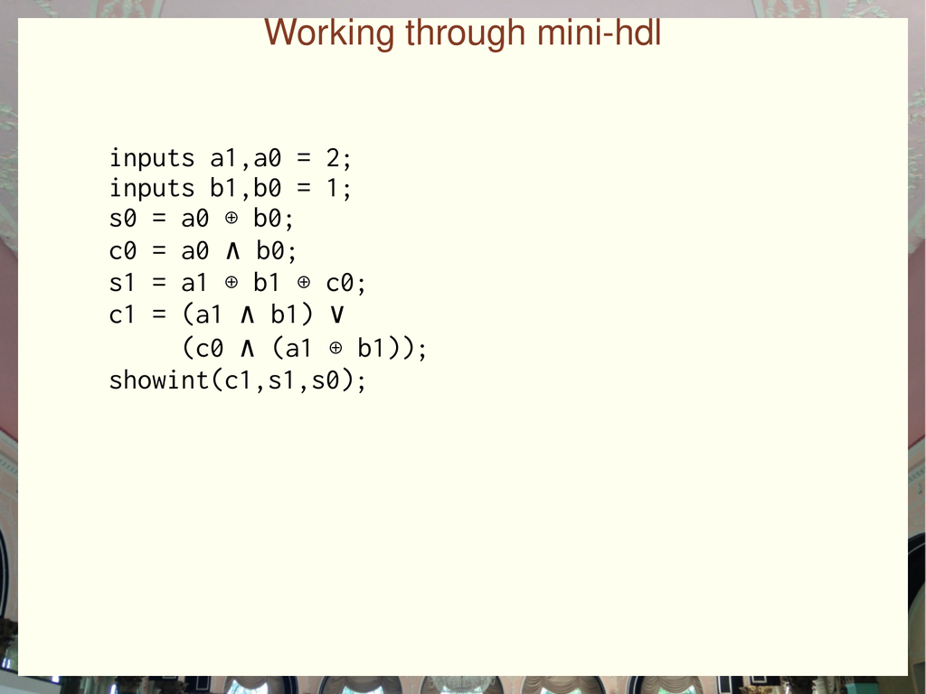

幻灯片 58 · 用两位行波进位加法器讲解语言实现Slide 58 · Explaining the implementation with a two-bit ripple-carry adder

**完整演示源代码 / Complete demo source: rca-2-hdl.rkt**

```
#lang mini-hdl
inputs a1,a0 = 2;
inputs b1,b0 = 1;
s0 = a0 ⊕ b0;
c0 = a0 ∧ b0;
s1 = a1 ⊕ b1 ⊕ c0;
c1 = (a1 ∧ b1) ∨
     (c0 ∧ (a1 ⊕ b1));
showint(c1,s1,s0);
```

**幻灯片文字 / Slide text**

```
Working through mini-hdl
inputs a1,a0 = 2;
inputs b1,b0 = 1;
s0 = a0 ⊕ b0;
c0 = a0 ∧ b0;
s1 = a1 ⊕ b1 ⊕ c0;
c1 = (a1 ∧ b1) ∨
     (c0 ∧ (a1 ⊕ b1));
showint(c1,s1,s0);
```

这里是一个示例程序，算是较短的版本，一个两位的行波进位加法器。首先发生的事，当然是把它变得更漂亮。这是解析器。好，它有 109 行代码，在那边用很小的字体显示出来。它基本上使用的是 lex 和 yacc 库……So here is a sample program, sort of a shorter version, a ripple carry adder with two bits, and the first thing that happens is, of course, we make it more beautiful. This is the parser Okay, and it's a It's 109 lines of code, and it's in a very small font over there, and it's basically using You know lex and yak library.

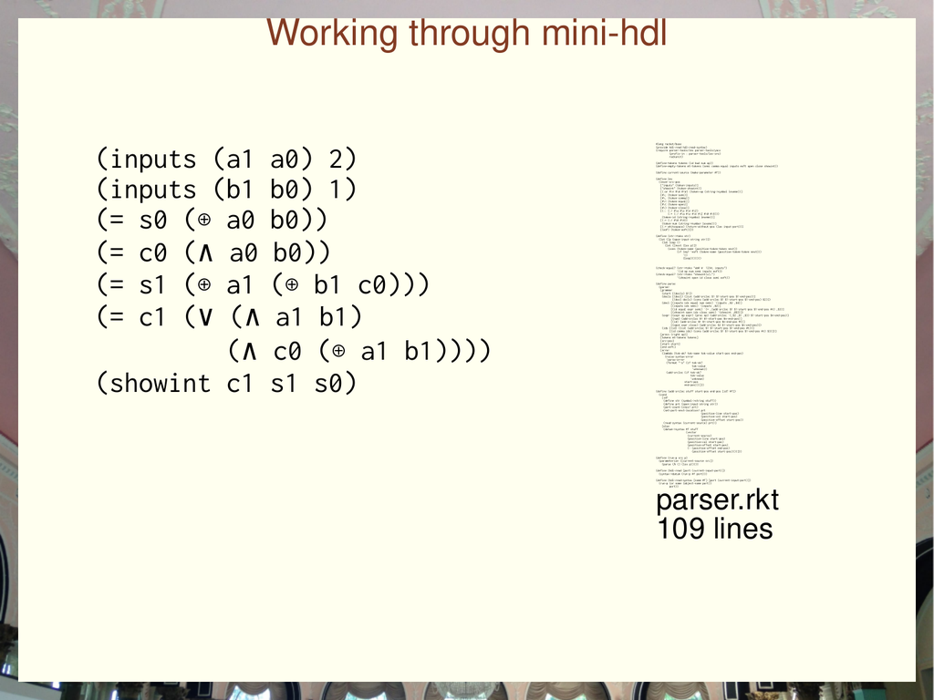

幻灯片 59 · 解析为带括号的形式；解析器只有 109 行Slide 59 · Parse into parenthesized forms; the parser is 109 lines

**完整演示源代码 / Complete demo source: parser.rkt**

```
#lang racket/base
(provide hdl-read hdl-read-syntax)
(require parser-tools/lex parser-tools/yacc
         (prefix-in : parser-tools/lex-sre)
         rackunit)

(define-tokens tokens (id kwd num op))
(define-empty-tokens mt-tokens (semi comma equal inputs eoft open close showint))

(define current-source (make-parameter #f))

(define lex
  (lexer-src-pos
   ["inputs" (token-inputs)]
   ["showint" (token-showint)]
   [(:or #\⊕ #\∧ #\∨) (token-op (string->symbol lexeme))]
   [#\; (token-semi)]
   [#\, (token-comma)]
   [#\= (token-equal)]
   [#\( (token-open)]
   [#\) (token-close)]
   [(:: (:/ #\a #\z #\A #\Z)
        (:* (:/ #\a #\z #\A #\Z #\0 #\9)))
    (token-id (string->symbol lexeme))]
   [(:+ (:/ #\0 #\9))
    (token-num (string->number lexeme))]
   [(:+ whitespace) (return-without-pos (lex input-port))]
   [(eof) (token-eoft)]))

(define (str->toks str)
  (let ([p (open-input-string str)])
    (let loop ()
      (let ([next (lex p)])
        (cons (token-name (position-token-token next))
              (if (eq? 'eoft (token-name (position-token-token next)))
                  '()
                  (loop)))))))


(check-equal? (str->toks "ab0 ∨  1234; inputs")
              '(id op num semi inputs eoft))
(check-equal? (str->toks "showint(x);")
              '(showint open id close semi eoft))

(define parse
  (parser
   [grammar
    (start [(decls) $1])
    (decls [(decl) (list (add-srcloc $1 $1-start-pos $1-end-pos))]
           [(decl decls) (cons (add-srcloc $1 $1-start-pos $1-end-pos) $2)])
    (decl [(inputs ids equal num semi) `(inputs ,$2 ,$4)]
          [(inputs ids semi) `(inputs ,$2)]
          [(id equal expr semi) `(= ,(add-srcloc $1 $1-start-pos $1-end-pos #t) ,$3)]
          [(showint open ids close semi) `(showint ,@$3)])
    (expr [(expr op expr) (prec op) (add-srcloc `(,$2 ,$1 ,$3) $1-start-pos $n-end-pos)]
          [(num) (add-srcloc $1 $1-start-pos $n-end-pos)]
          [(id) (add-srcloc $1 $1-start-pos $n-end-pos #t)]
          [(open expr close) (add-srcloc $2 $1-start-pos $n-end-pos)])
    (ids [(id) (list (add-srcloc $1 $1-start-pos $1-end-pos #t))]
         [(id comma ids) (cons (add-srcloc $1 $1-start-pos $1-end-pos #t) $3)])]
   [precs (right op)]
   [tokens mt-tokens tokens]
   [src-pos]
   [start start]
   [end eoft]
   [error
    (lambda (tok-ok? tok-name tok-value start-pos end-pos)
      (raise-syntax-error
       'parse-error
       (format "~s" (if tok-ok?
                        tok-value
                        'unknown))
       (add-srcloc (if tok-ok?
                       tok-value
                       'unknown)
                   start-pos
                   end-pos)))]))

(define (add-srcloc stuff start-pos end-pos [id? #f])
  (cond
    [id?
     (define str (symbol->string stuff))
     (define prt (open-input-string str))
     (port-count-lines! prt)
     (set-port-next-location! prt
                              (position-line start-pos)
                              (position-col start-pos)
                              (position-offset start-pos))
     (read-syntax (current-source) prt)]
    [else
     (datum->syntax #f stuff
                    (vector
                     (current-source)
                     (position-line start-pos)
                     (position-col start-pos)
                     (position-offset start-pos)
                     (- (position-offset end-pos)
                        (position-offset start-pos))))]))

(define (run-p src p)
  (parameterize ([current-source src])
    (parse (λ () (lex p)))))

(define (hdl-read [port (current-input-port)])
  (syntax->datum (run-p #f port)))

(define (hdl-read-syntax [name #f] [port (current-input-port)])
  (run-p (or name (object-name port))
         port))
```

**幻灯片文字 / Slide text**

```
Working through mini-hdl
(inputs (a1 a0) 2)
(inputs (b1 b0) 1)
(= s0 (⊕ a0 b0))
(= c0 (∧ a0 b0))
(= s1 (⊕ a1 (⊕ b1 c0)))
(= c1 (∨ (∧ a1 b1)
         (∧ c0 (⊕ a1 b1))))
(showint c1 s1 s0)
#lang racket/base
(provide hdl-read hdl-read-syntax)
(require parser-tools/lex parser-tools/yacc
         (prefix-in : parser-tools/lex-sre)
         rackunit)
(define-tokens tokens (id kwd num op))
(define-empty-tokens mt-tokens (semi comma equal inputs eoft open close showint))
(define current-source (make-parameter #f))
(define lex
  (lexer-src-pos
   ["inputs" (token-inputs)]
   ["showint" (token-showint)]
   [(:or #\⊕ #\∧ #\∨) (token-op (string->symbol lexeme))]
   [#\; (token-semi)]
   [#\, (token-comma)]
   [#\= (token-equal)]
   [#\( (token-open)]
   [#\) (token-close)]
   [(:: (:/ #\a #\z #\A #\Z)
        (:* (:/ #\a #\z #\A #\Z #\0 #\9)))
    (token-id (string->symbol lexeme))]
   [(:+ (:/ #\0 #\9))
    (token-num (string->number lexeme))]
   [(:+ whitespace) (return-without-pos (lex input-port))]
   [(eof) (token-eoft)]))
(define (str->toks str)
  (let ([p (open-input-string str)])
    (let loop ()
      (let ([next (lex p)])
        (cons (token-name (position-token-token next))
              (if (eq? 'eoft (token-name (position-token-token next)))
                  '()
                  (loop)))))))
(check-equal? (str->toks "ab0 ∨  1234; inputs")
              '(id op num semi inputs eoft))
(check-equal? (str->toks "showint(x);")
              '(showint open id close semi eoft))
(define parse
  (parser
   [grammar
    (start [(decls) $1])
    (decls [(decl) (list (add-srcloc $1 $1-start-pos $1-end-pos))]
           [(decl decls) (cons (add-srcloc $1 $1-start-pos $1-end-pos) $2)])
    (decl [(inputs ids equal num semi) `(inputs ,$2 ,$4)]
          [(inputs ids semi) `(inputs ,$2)]
          [(id equal expr semi) `(= ,(add-srcloc $1 $1-start-pos $1-end-pos #t) ,$3)]
          [(showint open ids close semi) `(showint ,@$3)])
    (expr [(expr op expr) (prec op) (add-srcloc `(,$2 ,$1 ,$3) $1-start-pos $n-end-pos)]
          [(num) (add-srcloc $1 $1-start-pos $n-end-pos)]
          [(id) (add-srcloc $1 $1-start-pos $n-end-pos #t)]
          [(open expr close) (add-srcloc $2 $1-start-pos $n-end-pos)])
    (ids [(id) (list (add-srcloc $1 $1-start-pos $1-end-pos #t))]
         [(id comma ids) (cons (add-srcloc $1 $1-start-pos $1-end-pos #t) $3)])]
   [precs (right op)]
   [tokens mt-tokens tokens]
   [src-pos]
   [start start]
   [end eoft]
   [error
    (lambda (tok-ok? tok-name tok-value start-pos end-pos)
      (raise-syntax-error
       'parse-error
       (format "~s" (if tok-ok?
                        tok-value
                        'unknown))
       (add-srcloc (if tok-ok?
                       tok-value
                       'unknown)
                   start-pos
                   end-pos)))]))
(define (add-srcloc stuff start-pos end-pos [id? #f])
  (cond
    [id?
     (define str (symbol->string stuff))
     (define prt (open-input-string str))
     (port-count-lines! prt)
     (set-port-next-location! prt
                              (position-line start-pos)
                              (position-col start-pos)
                              (position-offset start-pos))
     (read-syntax (current-source) prt)]
    [else
     (datum->syntax #f stuff
                    (vector
                     (current-source)
                     (position-line start-pos)
                     (position-col start-pos)
                     (position-offset start-pos)
                     (- (position-offset end-pos)
                        (position-offset start-pos))))]))
(define (run-p src p)
  (parameterize ([current-source src])
    (parse (λ () (lex p)))))
(define (hdl-read [port (current-input-port)])
  (syntax->datum (run-p #f port)))
(define (hdl-read-syntax [name #f] [port (current-input-port)])
  (run-p (or name (object-name port))
         port))parser.rkt
109 lines
```

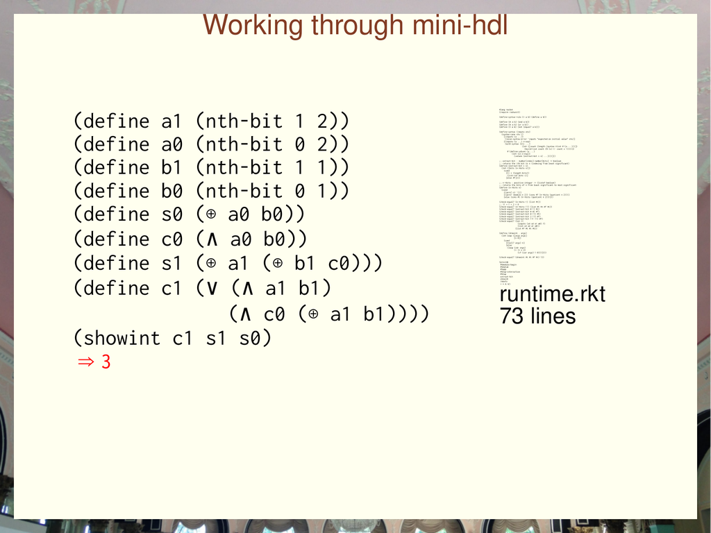

幻灯片 60 · 普通运行时：输入声明展开为定义，共 73 行实现Slide 60 · Ordinary runtime: inputs expand into definitions; 73 implementation lines

**完整演示源代码 / Complete demo source: runtime.rkt**

```
#lang racket
(require rackunit)

(define-syntax-rule (= a b) (define a b))

(define (∧ a b) (and a b))
(define (∨ a b) (or a b))
(define (⊕ a b) (not (equal? a b)))

(define-syntax (inputs stx)
  (syntax-case stx ()
    [(inputs (a ...))
     (raise-syntax-error 'inputs "expected an initial value" stx)]
    [(inputs (a ...) n-exp)
     (with-syntax ([(i ...)
                    (let ([count (length (syntax->list #'(a ...)))])
                      (build-list count (λ (x) (- count x 1))))])
       #'(define-values (a ...)
           (let ([n n-exp])
             (values (extract-bit i n) ...))))]))

;; extract-bit : number[index] number[bits] -> boolean
;; returns the ith bit in n (indexing from least significant)
(define (extract-bit i n)
  (let ([bits (n->bits n)])
    (cond
      [(< i (length bits))
       (list-ref bits i)]
      [else #f])))

;; n->bits : positive-integer -> (listof boolean)
;; returns the bits of n from least significant to most significant
(define (n->bits n)
  (cond
    [(zero? n) '()]
    [(zero? (modulo n 2)) (cons #f (n->bits (quotient n 2)))]
    [else (cons #t (n->bits (quotient n 2)))]))

(check-equal? (n->bits 1) (list #t))
;; 11 = 1 + 2 + 8
(check-equal? (n->bits 11) (list #t #t #f #t))
(check-equal? (extract-bit 0 1) #t)
(check-equal? (extract-bit 0 0) #f)
(check-equal? (extract-bit 0 11) #t)
(check-equal? (extract-bit 2 11) #f)
(check-equal? (extract-bit 111 11) #f)
(check-equal? (let ()
                (inputs (a3 a2 a1 a0) 7)
                (list a3 a2 a1 a0))
              (list #f #t #t #t))

(define (showint . args)
  (let loop ([args args]
             [n 0])
    (cond
      [(null? args) n]
      [else
       (loop (cdr args)
             (+ (* n 2)
                (if (car args) 1 0)))])))

(check-equal? (showint #t #t #f #t) 13)

(provide
 #%module-begin
 #%datum
 #%app
 #%top-interaction
 #%top
 extract-bit
 showint
 inputs
 = ⊕ ∧ ∨)
```

**幻灯片文字 / Slide text**

```
Working through mini-hdl
(define a1 (nth-bit 1 2))
(define a0 (nth-bit 0 2))
(define b1 (nth-bit 1 1))
(define b0 (nth-bit 0 1))
(define s0 (⊕ a0 b0))
(define c0 (∧ a0 b0))
(define s1 (⊕ a1 (⊕ b1 c0)))
(define c1 (∨ (∧ a1 b1)
              (∧ c0 (⊕ a1 b1))))
(showint c1 s1 s0)
 ⇒ 3
#lang racket
(require rackunit)
(define-syntax-rule (= a b) (define a b))
(define (∧ a b) (and a b))
(define (∨ a b) (or a b))
(define (⊕ a b) (not (equal? a b)))
(define-syntax (inputs stx)
  (syntax-case stx ()
    [(inputs (a ...))
     (raise-syntax-error 'inputs "expected an initial value" stx)]
    [(inputs (a ...) n-exp)
     (with-syntax ([(i ...)
                    (let ([count (length (syntax->list #'(a ...)))])
                      (build-list count (λ (x) (- count x 1))))])
       #'(define-values (a ...)
           (let ([n n-exp])
             (values (extract-bit i n) ...))))]))
;; extract-bit : number[index] number[bits] -> boolean
;; returns the ith bit in n (indexing from least significant)
(define (extract-bit i n)
  (let ([bits (n->bits n)])
    (cond
      [(< i (length bits))
       (list-ref bits i)]
      [else #f])))
;; n->bits : positive-integer -> (listof boolean)
;; returns the bits of n from least significant to most significant
(define (n->bits n)
  (cond
    [(zero? n) '()]
    [(zero? (modulo n 2)) (cons #f (n->bits (quotient n 2)))]
    [else (cons #t (n->bits (quotient n 2)))]))
(check-equal? (n->bits 1) (list #t))
;; 11 = 1 + 2 + 8
(check-equal? (n->bits 11) (list #t #t #f #t))
(check-equal? (extract-bit 0 1) #t)
(check-equal? (extract-bit 0 0) #f)
(check-equal? (extract-bit 0 11) #t)
(check-equal? (extract-bit 2 11) #f)
(check-equal? (extract-bit 111 11) #f)
(check-equal? (let ()
                (inputs (a3 a2 a1 a0) 7)
                (list a3 a2 a1 a0))
              (list #f #t #t #t))
(define (showint . args)
  (let loop ([args args]
             [n 0])
    (cond
      [(null? args) n]
      [else
       (loop (cdr args)
             (+ (* n 2)
                (if (car args) 1 0)))])))
(check-equal? (showint #t #t #f #t) 13)
(provide
 #%module-begin
 #%datum
 #%app
 #%top-interaction
 #%top
 extract-bit
 showint
 inputs
 = ⊕ ∧ ∨)runtime.rkt
73 lines
```

也就是 Racket 自带的库。然后，一旦得到这种形式，宏就开始发挥作用。这就是那个程序的宏转换所做的事：inputs，那条 inputs 声明，只会变成一系列定义，每个变量一个；等号其实就是 define；而 nth-bit 是这门小编程语言运行期系统中的一个函数。That racket comes with all right, and then once we have it in that form, then the macros come in and this is what this is. The macro transformation for that program does so inputs that inputs declaration just turns into a bunch of definitions. one for each variable equals really was just defined, and NTH bit is a function in the runtime system for this little programming language.

所以，这边这 73 行代码，实现了 xor、楔形运算以及其他布尔运算，还包括进行转换的那些宏。你们大概可以想象，那些宏并不是特别复杂，对吧。它只是调用 nth-bit，传入 0，或者 n，然后再传入用于初始化的那个数字。So this is the 73 lines of code over Here is the implementation of those of the Xor and the wedge and whatever those boolean operations, as well as the Trans, those macros that did the transformation, you can kind of imagine that those macros are not super complicated. right. It's just calling nth bit you know with zero with you know n and then and then the number it was initialized with.

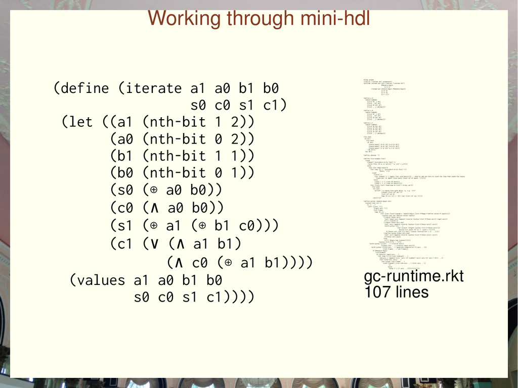

幻灯片 61 · 门延迟版本：展开为迭代求稳定值的函数，共 107 行Slide 61 · Gate-delay version: expand into a fixed-point iteration; 107 lines

**完整演示源代码 / Complete demo source: gc-runtime.rkt**

```
#lang scheme
(require "runtime.rkt" schemeunit)
(provide (except-out (all-from-out "runtime.rkt")
                     #%module-begin
                     ∧ ∨ ⊕)
         (rename-out [module-begin #%module-begin]
                     [u:∨ ∨]
                     [u:∧ ∧]
                     [u:⊕ ⊕]))

(define u:∨
  (match-lambda*
    [(list #t _) #t]
    [(list _ #t) #t]
    [(list #f #f) #f]
    [(list _ _) unknown]))

(define u:∧
  (match-lambda*
    [(list #f _) #f]
    [(list _ #f) #f]
    [(list #t #t) #t]
    [(list _ _) unknown]))

(define u:⊕
  (match-lambda*
    [(list #t #t) #f]
    [(list #f #f) #f]
    [(list #f #t) #t]
    [(list #t #f) #t]
    [(list _ _) unknown]))

(for-each
 (λ (b1)
   (for-each
    (λ (b2)
      (check-equal? (∨ b1 b2) (u:∨ b1 b2))
      (check-equal? (∧ b1 b2) (u:∧ b1 b2))
      (check-equal? (⊕ b1 b2) (u:⊕ b1 b2)))
    '(#t #f)))
 '(#t #f))

(define unknown '?)

(define (run-example func)
  (cond
    [(equal? (procedure-arity func) 1)
     (void (func (λ (x y) (printf "~a ~a\n" x y))))]
    [else
      (let ([ht (make-hash)])
        (let loop ([i (- (procedure-arity func) 1)]
                   [bools '()])
          (cond
            [(zero? i)
             (let ([depth (+ 1 (apply func void bools))]) ;; need to add one here to count the step that seeds the inputs
               (hash-set! ht depth (cons bools (hash-ref ht depth '()))))]
            [else
             (loop (- i 1) (cons #t bools))
             (loop (- i 1) (cons #f bools))]))
        (let ([vals (sort (hash-map ht list) < #:key car)])
          (for-each
           (λ (val)
             (printf "~a inputs have gate delay ~a, e.g. ~s\n"
                     (length (list-ref val 1))
                     (list-ref val 0)
                     (map (λ (x) (if x 1 0)) (car (list-ref val 1)))))
           vals)))]))

(define-syntax (module-begin stx)
  (syntax-case stx ()
    [(_ a ...)
     (let* ([vars '()]
            [input-vars '()]
            [let-frames
             (map (λ (x)
                    (let ([ans (local-expand x 'module-begin (list #'#%app #'define-values #'inputs))])
                      (syntax-case ans (define-values inputs)
                        [(inputs these-vars)
                         (set! input-vars (append (reverse (syntax->list #'these-vars)) input-vars))
                         #'[() (values)]]
                        [(inputs these-vars exp)
                         (set! vars (append (reverse (syntax->list #'these-vars)) vars))
                         (with-syntax ([(i ...)
                                        (let ([count (length (syntax->list #'these-vars))])
                                          (build-list count (λ (x) (- count x 1))))])
                           #'[these-vars (let ([n exp]) (values (extract-bit i n) ...))])]
                        [(define-values these-vars exp)
                         (set! vars (append (reverse (syntax->list #'these-vars)) vars))
                         #'[these-vars exp]]
                        [exp
                         #'[() (begin exp (values))]])))
                  (syntax->list #'(a ...)))])
       (with-syntax ([(vars ...) (reverse vars)]
                     [(input-vars ...) (reverse input-vars)])
         (with-syntax ([(old-vars ...) (generate-temporaries #'(vars ...))]
                       [(let-frames ...) let-frames])
           #'(#%module-begin
              (run-example
               (λ (details input-vars ...)
                 (let loop ([i 0] [vars unknown] ...)
                   (details i (append (list 'vars (if (symbol? vars) vars (if vars 1 0))) ...))
                   (let ([old-vars vars] ...)
                     (let-values (let-frames ...)
                       (cond [(equal? (list old-vars ...) (list vars ...))
                              i]
                             [else
                              (loop (+ i 1) vars ...)]))))))))))]))
```

**幻灯片文字 / Slide text**

```
Working through mini-hdl
(define (iterate a1 a0 b1 b0
                 s0 c0 s1 c1)
 (let ((a1 (nth-bit 1 2))
(a0 (nth-bit 0 2))
(b1 (nth-bit 1 1))
(b0 (nth-bit 0 1))
(s0 (⊕ a0 b0))
(c0 (∧ a0 b0))
(s1 (⊕ a1 (⊕ b1 c0)))
(c1 (∨ (∧ a1 b1)
       (∧ c0 (⊕ a1 b1))))
  (values a1 a0 b1 b0
          s0 c0 s1 c1))))
#lang scheme
(require "runtime.rkt" schemeunit)
(provide (except-out (all-from-out "runtime.rkt")
                     #%module-begin
                     ∧ ∨ ⊕)
         (rename-out [module-begin #%module-begin]
                     [u:∨ ∨]
                     [u:∧ ∧]
                     [u:⊕ ⊕]))
(define u:∨
  (match-lambda*
    [(list #t _) #t]
    [(list _ #t) #t]
    [(list #f #f) #f]
    [(list _ _) unknown]))
(define u:∧
  (match-lambda*
    [(list #f _) #f]
    [(list _ #f) #f]
    [(list #t #t) #t]
    [(list _ _) unknown]))
(define u:⊕
  (match-lambda*
    [(list #t #t) #f]
    [(list #f #f) #f]
    [(list #f #t) #t]
    [(list #t #f) #t]
    [(list _ _) unknown]))
(for-each
 (λ (b1)
   (for-each
    (λ (b2)
      (check-equal? (∨ b1 b2) (u:∨ b1 b2))
      (check-equal? (∧ b1 b2) (u:∧ b1 b2))
      (check-equal? (⊕ b1 b2) (u:⊕ b1 b2)))
    '(#t #f)))
 '(#t #f))
(define unknown '?)
(define (run-example func)
  (cond
    [(equal? (procedure-arity func) 1)
     (void (func (λ (x y) (printf "~a ~a\n" x y))))]
    [else
      (let ([ht (make-hash)])
        (let loop ([i (- (procedure-arity func) 1)]
                   [bools '()])
          (cond
            [(zero? i)
             (let ([depth (+ 1 (apply func void bools))]) ;; need to add one here to count the step that seeds the inputs
               (hash-set! ht depth (cons bools (hash-ref ht depth '()))))]
            [else
             (loop (- i 1) (cons #t bools))
             (loop (- i 1) (cons #f bools))]))
        (let ([vals (sort (hash-map ht list) < #:key car)])
          (for-each
           (λ (val)
             (printf "~a inputs have gate delay ~a, e.g. ~s\n"
                     (length (list-ref val 1))
                     (list-ref val 0)
                     (map (λ (x) (if x 1 0)) (car (list-ref val 1)))))
           vals)))]))
(define-syntax (module-begin stx)
  (syntax-case stx ()
    [(_ a ...)
     (let* ([vars '()]
            [input-vars '()]
            [let-frames
             (map (λ (x)
                    (let ([ans (local-expand x 'module-begin (list #'#%app #'define-values #'inputs))])
                      (syntax-case ans (define-values inputs)
                        [(inputs these-vars)
                         (set! input-vars (append (reverse (syntax->list #'these-vars)) input-vars))
                         #'[() (values)]]
                        [(inputs these-vars exp)
                         (set! vars (append (reverse (syntax->list #'these-vars)) vars))
                         (with-syntax ([(i ...)
                                        (let ([count (length (syntax->list #'these-vars))])
                                          (build-list count (λ (x) (- count x 1))))])
                           #'[these-vars (let ([n exp]) (values (extract-bit i n) ...))])]
                        [(define-values these-vars exp)
                         (set! vars (append (reverse (syntax->list #'these-vars)) vars))
                         #'[these-vars exp]]
                        [exp
                         #'[() (begin exp (values))]])))
                  (syntax->list #'(a ...)))])
       (with-syntax ([(vars ...) (reverse vars)]
                     [(input-vars ...) (reverse input-vars)])
         (with-syntax ([(old-vars ...) (generate-temporaries #'(vars ...))]
                       [(let-frames ...) let-frames])
           #'(#%module-begin
              (run-example
               (λ (details input-vars ...)
                 (let loop ([i 0] [vars unknown] ...)
                   (details i (append (list 'vars (if (symbol? vars) vars (if vars 1 0))) ...))
                   (let ([old-vars vars] ...)
                     (let-values (let-frames ...)
                       (cond [(equal? (list old-vars ...) (list vars ...))
                              i]
                             [else
                              (loop (+ i 1) vars ...)]))))))))))]))
gc-runtime.rkt
107 lines
```

所以这些宏并不复杂，都是很简单的转换，这就是代码短的原因。然后，对于门计数语言，它会以完全不同的方式展开，因为我想能够计算次数，你知道，我想能够打断值在电路中流动的过程。So the macros are not very complicated. They're pretty simple transformations, and that's why the code's short and then it expands in a totally different way for the gate count language because I want to be able to count how many times you know, I want to be able to like interrupt the process of the values flowing through.

因此，它对布尔运算采用了不同的实现，因为现在它们接收的不只是布尔值，还会接收“我还不知道这个值是什么”。而且，它们有这种很好的短路行为。So it has a different implementation of the boolean operations because they don't just get booleans now they also get the I don't know what the value is yet, and they have this nice short circuiting behavior.

所以，如果你给……比如给 and 一个假值和一个“我不知道”，它会说是假，对吧，因为它不需要知道另一个值是什么。因此，这个 iterate 函数会被反复调用来查看结果，持续下去，直到某一轮循环中结果不再变化。然后，底部有一个小循环，就是最下面那块可怕地向右漂移的东西，我不知道你们看不看得见。So if you give if you give like what if you give and a false and an, I don't know it says false right because it doesn't need to know what the other one is, and so you so this iterate function you know it just gets called multiple times to see, and then it keeps going until the results don't change in one loop, and then so there's a little loop that the bottom that bottom thing there where the horrible rightward drift, I don't know if you can see it there.

那就是多次调用这个生成出来的函数的小循环。这就是在门计数编程语言中，同一个程序的宏展开结果。所以，这个展开稍微有点不同，但实际上仍然是一个非常简单的展开，这就是它只有 107 行的原因。然后，还有这里的这些行。That's the little loop that's calling this generated function multiple times, and this is This is what the macros expand to for the same program in the gate count programming language. so this expenses you know slightly different, but really it's still a very simple expansion, and that's why it's only 107 lines. so and then there's another these lines right here.

## 择优挑选Cherry Picking

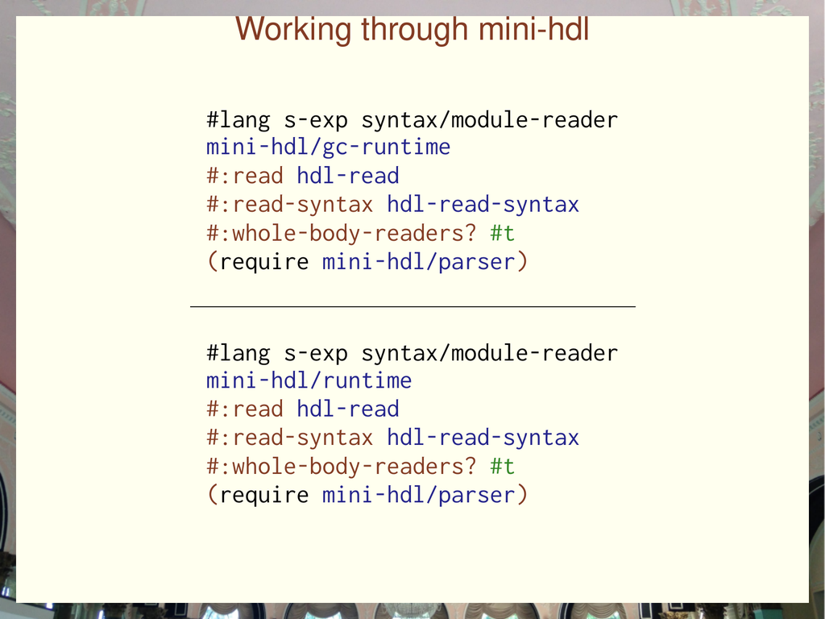

幻灯片 62 · 用语法读取器声明把解析器和两种运行时连接起来Slide 62 · Reader declarations connect the parser to the two runtimes

**完整演示源代码 / Complete demo source: reader.rkt**

```
#lang s-exp syntax/module-reader
mini-hdl/gc-runtime
#:read hdl-read
#:read-syntax hdl-read-syntax
#:whole-body-readers? #t
(require mini-hdl/parser)
```

**完整演示源代码 / Complete demo source: reader.rkt**

```
#lang s-exp syntax/module-reader
mini-hdl/runtime
#:read hdl-read
#:read-syntax hdl-read-syntax
#:whole-body-readers? #t
(require mini-hdl/parser)
```

**幻灯片文字 / Slide text**

```
Working through mini-hdl
#lang s-exp syntax/module-reader
mini-hdl/gc-runtime
#:read hdl-read
#:read-syntax hdl-read-syntax
#:whole-body-readers? #t
(require mini-hdl/parser)
#lang s-exp syntax/module-reader
mini-hdl/runtime
#:read hdl-read
#:read-syntax hdl-read-syntax
#:whole-body-readers? #t
(require mini-hdl/parser)
```

这是一门小小的元数据编程语言，基本上负责把解析器拼接起来，告诉系统：我的解析器在那边，其他文件在那边，这是解析器导出的名称，诸如此类。把所有这些合在一起，这个 Mini HDL 的实现大约有 300 行代码。This is a little metadata programming language that basically stitches together the parser and says like my parser's over there and my other files are over there, and here's how here's the exported name of the parser and whatever. So you put all that together. It's like about 300 lines of code for that implementation of Mini HDL.

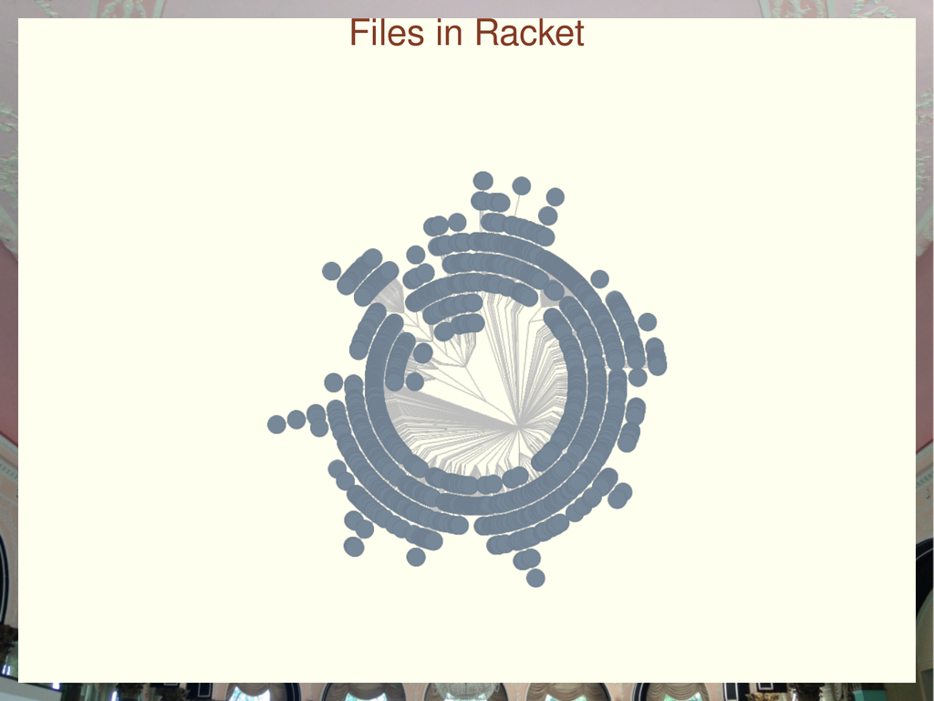

幻灯片 63 · Racket 标准发行版的文件目录树Slide 63 · The file tree of the standard Racket distribution

**幻灯片文字 / Slide text**

```
Files in Racket
```

好，这是一张 Racket 标准发行版目录结构的图。中间那个看起来像结的小东西是这棵树的根，圆圈则是文件。现在我要根据这些文件所使用的编程语言，给圆圈上色。我们之所以能让 Racket 拥有这么多配套功能，很大程度上就是这个原因。它确实有一些，内置了很多现成的配套功能。Okay, all right, So this is a picture of the directory structure of the standard distribution of racket, and that little not looking thing in the middle is the root of the tree, and the circles are the files, and so what I'm going to do now is color in the circles based on the programming language that they're that they're written in, and this is you know like a lot of the reason why we're able to make racket have the batteries that it has, and it's got some, it's got a lot of batteries included in it.

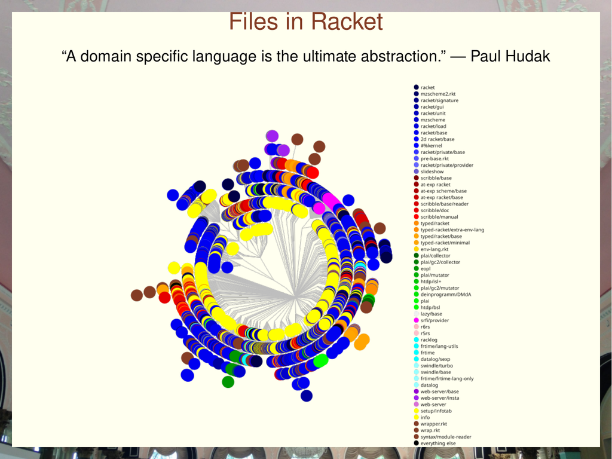

幻灯片 64 · 按语言着色的文件树；Paul Hudak：领域特定语言是终极抽象Slide 64 · Files colored by language; Paul Hudak: a domain-specific language is the ultimate abstraction

**幻灯片文字 / Slide text**

```
Files in Racket
“A domain specific language is the ultimate abstraction.” — Paul Hudak
```

这是因为我们能够利用宏系统，并且能用自己认为最方便的任何编程语言来写东西。这里肯定存在某种幂律现象。底下这个黑色的“其他所有东西”，包含一大堆疯狂的小型一次性编程语言。It's because we're able to leverage the macro system and the fact that we can write things in whatever programming language we find most convenient, and there's definitely a power law thing happening here. This everything else black thing on the bottom contains a bunch of crazy, little one off programming languages in it.

好，这张幻灯片总让我想到 Paul Hudak，你们可能还记得，昨天是他的生日。这是他的一句话。他在 Haskell 的背景下，对领域特定语言做了大量研究。好，最后让我留给大家两个想法。Okay, And this slide always makes me think of Paulhood x the one whose birthday was yesterday, as you may recall, and this is a quote that he made. He did a lot of work on domain specific languages in the context of Haskell all right. So let me just leave you with two thoughts.

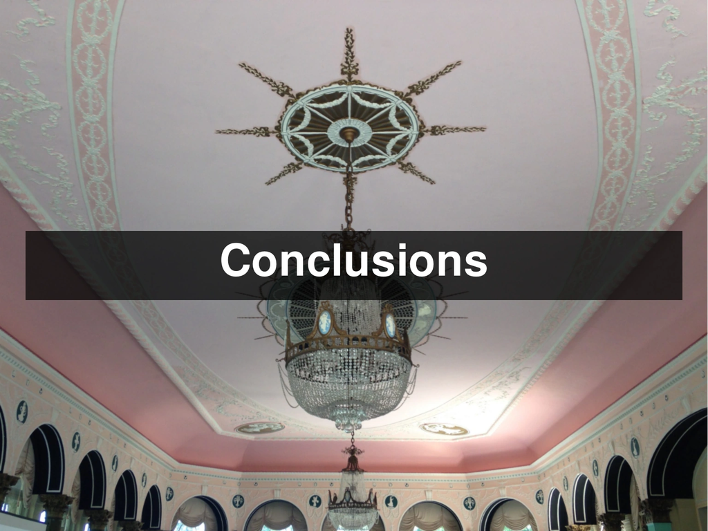

幻灯片 65 · 结语Slide 65 · Conclusions

**幻灯片文字 / Slide text**

```
Conclusions
```

宏在很大程度上让我们这个不算很大的团队能够构建出 Racket。宏系统里有很多东西，很有意思：如果你想动手折腾，想构建一门编程语言，它很有意思；如果你是研究如何构建编程语言的研究人员，它也很有意思。而如果你需要一门新的编程语言——你知道，每个人都需要——也许你该试试，也许你该试试 Racket。好。Macros are a lot of what makes us able to as a not very large team build bracket, and there's a lot going on there in the macro system. That's both interesting, like if you want to do some hacking and you want to build a programming language and interesting if you're a researcher studying how to build programming languages, and if you need a new programming language, you know and everybody does, Maybe you should give, maybe you should give racket a try all right.

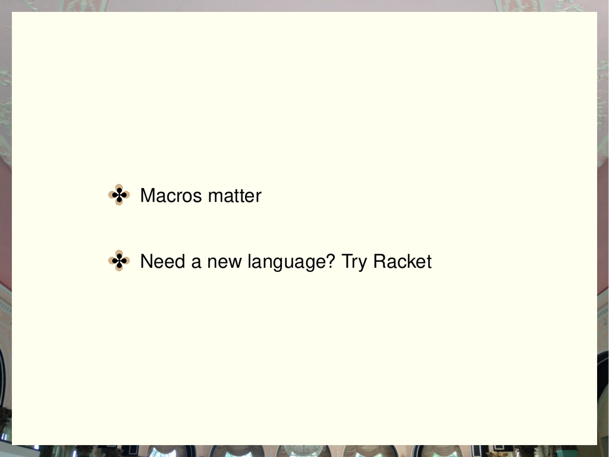

幻灯片 66 · 宏很重要；需要新语言时，试试 RacketSlide 66 · Macros matter; need a new language? Try Racket

**幻灯片文字 / Slide text**

```
✤
✤Macros matter
✤
✤Need a new language? Try Racket
```

## 第 1—3 章Chapters 1-3

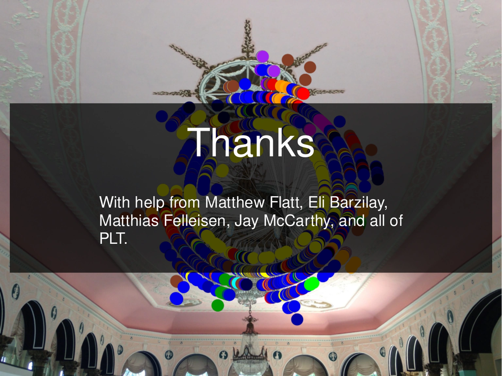

幻灯片 67 · 致谢：Matthew Flatt、Eli Barzilay、Matthias Felleisen、Jay McCarthy 与 PLTSlide 67 · Thanks: Matthew Flatt, Eli Barzilay, Matthias Felleisen, Jay McCarthy and PLT

**幻灯片文字 / Slide text**

```
Thanks
With help from Matthew Flatt, Eli Barzilay,
Matthias Felleisen, Jay McCarthy, and all of
PLT.
```

谢谢。线程构造采用的是绿色线程的风格，所以它有……它的方式不是……它没有像 Python 之类那样的 GIL。不过，线程构造是用于并发的，比如编写图形用户界面，以及网络之类的东西，也就是你想把非确定性引入编程语言的时候。另外，还有两个单独用于并行的构造，一个是 futures，另一个叫 places。它们有不同的取舍。Thanks, Foreign applause construct is green threads style, so it has a, it doesn't do it the way it doesn't have the gill, the way python, whatever do, but so the threading construct is for concurrency, so for like programming guise and with you know, networking and stuff like that where you're interested in bringing non determinism into the programming language, and then there's two separate constructs for parallelism, One is futures, and one is called places, and they have different trade offs.

这些取舍与这样一个事实有关：我们的运行期系统大约有 15 年历史了，而且针对顺序执行的情况做了大量优化。其中一个……对，之后我可以再多讲讲。Having to do with the fact that our runtime system is about 15 years old and heavily optimized for the sequential case, and one of them. Yeah, I can tell you more about them later.

不过，大体上，我们以这两种不同的方式支持并行。其中一种会克隆运行期系统的状态，另一种则大概知道运行期系统状态中的哪些部分可以安全地并行运行。它们有不同的限制，也有不同的取舍。But roughly we have support for parallelism in this two different ways, and one of them clones the runtime system state, and one of them kind of knows which part of the runtime system state is safe to run in parallel, and they have different limitations and different trade offs.

## Racket 程序分析：理解 JavaScript 中的互操作性Rocket Program Analysis: Understanding Interoperability in JavaScript

这取决于你实际的并行应用是什么样的。比如，Racket 的构建系统完全是并行的，用的是 places，也就是克隆运行期系统状态的那一种。对，还有什么……没有？哦，抱歉，问题是有没有什么东西……也许我们应该先把问题说完，我打断你了。对，音乐。好，问题是，有没有什么具有类似能力、可以在浏览器里使用的东西。Depending on you know what your actual parallel application looks like so like, and the build system for rocket is all parallel using places the cloning, the runtime system state yep anything No, Oh sorry, the question was if there's anything, Maybe we should finish it. I should I cut you off. Yeah music. Well, the questions whether there's anything with a similar power that you can use in a browser.

我觉得这个问题由我来回答很危险。浏览器里有 JavaScript，它具有一定的能力，不过我会说，那种能力和 Racket 不一样。也许我应该说到这里就好。我也不知道。有一个项目可以运行 Racket，那是一个把 Racket 编译成 JavaScript 的编译器，叫作 Whalesong，可以让你在浏览器里运行一部分，相当一部分的 Racket。对。I feel like that's a very dangerous question for me to answer. There's javascript in browsers, and it has a level of power, which I would say is different than racket. Maybe I should leave it at that. I don't know, so there's a, There's a project that to run racket, That's a job racket to Javascript compiler called Whale song, which lets you run some much of racket in a browser. Ies.

对，有一个 C FFI。问题是，Racket 对那些不是用 Racket 编写的语言，有没有良好的互操作性，对吧。毫无疑问，相比那些用 Racket 编写的语言，这方面的互操作性要差一些。你知道，当语言借助宏一起实现时，它们能够在更高层次上协作。我没有讲模块系统，不过它们可以在更高的层次交互，而不只是传统互操作方式中你所预期的那种底层的、最低共同标准上的交互。Yeah, so there's a, There's a CFFI. The question is whether or not Racket has a good interoperability story for languages that are not written using racket right, and definitely the interoperability story is worse than it is for languages that are You know, the languages can cooperate at a higher level when they when they're implemented together with macros, because I didn't talk about the module system, but they can they can interact at higher levels than just the kind of low level lowest common denominator that you expect from more traditional interop stories.

不过，我们也有一个 C FFI 接口，里面有一些有意思的巧妙设计，是 Eli Barzilay 做的。有些巧妙之处与不必总是需要 C 编译器有关，这使得……不过，它就是一个 C FFI，也许就是你所熟悉的那种。类型方面怎么……？But we also have a We have a C FFI interface. That's got some interesting clever, Ellie Barsley did it, It's got some interesting cleverness in there having to do with not needing a C compiler all the time that makes, but it's a CFFI that That's maybe what you're used to types of how does so?

问题是，在 Typed Racket 和无类型 Racket 之间，用户自定义类型的契约生成是如何工作的。它工作得很好。对于你能用 Typed Racket 自己定义的每一种类型，Typed Racket 的类型系统都知道如何生成契约。Dave Thomas 问，类型系统本身可扩展吗？没有，它的可扩展程度，并没有像一个深深沉浸于 Racket 宏世界的人……The question is how the contract generation works with user defined types between typed bracket and untyped bracket, and it works fine the the typed racket type system knows how to generate contracts for every type that you could define yourself using type track it dave. Thomas is the type system itself extensible, Not it's not as extensible as someone who's steeped in the macro world of racket.

所希望的那样高，对吧。比如，Racket 的模式匹配器允许你定义新种类的模式，并把它们加进去。你可能希望，一个秉承 Racket 精神的类型系统，能让你提供新的类型规则，比如用来定义新的东西。但目前它做不到，虽然我认为它可以，而且应该做到。实现模式匹配器扩展机制的那个人，也实现了 Typed Racket，我觉得你真的该着手做这个了。Might wish it were right in the sense that like for example, the pattern matcher in racket. Lets you define new kinds of patterns that you can add in, and you might hope that a type system in the spirit of racket would let you give new type rules say to define new things which it doesn't currently do, although I think it could and should, and the guy who implemented the thing that does the pattern matchers, the extensibility in the pattern matcher also implemented typed racket and I think you should really get on that.

你知道，类型层面的宏，以及一种定义可扩展类型系统的方式，似乎都是非常酷、值得拥有的东西，但我们目前还没有。它可以按更传统的方式扩展，比如用户自定义类型，也就是你在普通类型系统里会预期到的那些。对，这个问题是——我会大幅转述一下。You know the macros at the type level and in a way of defining an extensible type system seem like something that would be really cool to have, but we don't have it right now. It's extensible in the more traditional ways of like user defined types that you expect from a normal type system. Yeah, the question is and I will paraphrase this a lot.

你允许别人往编译器里添加东西，现在他们就能弄坏你所有的程序，能把一切都弄坏。答案是，是的。如果你知道，我们……我的意思是，在某种意义上，我不知道，我们好像把程序变糟的问题弄得更糟了，因为以前只有少数受信任的人有能力扩展编译器，而现在我们却说，让大家都来扩展编译器，对吧。所以，从某种意义上说，这让程序更糟了。不过，我觉得，比一个……这是“更糟就是更好”的另一种变体，也许是以一种更好的方式变糟。You've let somebody add things to the compiler and now they can break all of your programs, they can break all the things, and the answer is yes, if you know we've I mean in some sense, I don't know if I we sort of made the program worse problem worse because it used to be that You know only the trusted few had the power to extend the compiler, and now we're saying let's all extend the compiler right and so you know that in some sense, makes the program worse, but I think worse than a, That's a different variation on horses better, maybe worse in a better way.

所以，对，我认为所有那些问题都存在，而这是个有意思的研究课题。现在我们有了一个平台，可以研究如何做得更好。对，所以，我不知道，也许这就是最令人满意的回答。不过，哪里……问题是这张图来自哪里？你指的是背景，不是……对，那是餐厅里的。图？So so Yeah, I think all those problems are there and that's an interesting thing to study, and now we have a platform to study it. how we can do better. Yeah, then so I don't know maybe that's the most satisfying answer, but where's the question is where is this image from you mean the the the the background not Yeah, that's from the lunchroom foreign the graph.

哦，我用了一个 Racket 程序，还有，你知道，neato，它是 Graphviz 自带的。dot，你们可能听说过。我用它来实际安排这个图的布局，而数据是用一个 Racket 程序获取的。当然了。好。Oh I use a racket program and you know nito the which comes with a graph. Is you know Dot, you may have heard of to actually lay out the actual graph, but a rocket program did sort of get the data. Of course, okay,

Host

让我们感谢演讲者，谢谢。Let's thank the speaker, thank you

转录工具：https://www.appblit.com/quickscribeTranscribed with https://www.appblit.com/quickscribe